# Gather

```python
#import packages

import pandas as pd
import numpy as np
import requests
import os
import matplotlib.pyplot as plt
import tweepy
import json
```

```python
#read WeRateDogs into a dataframe

wrd_archive = pd.read_csv('twitter-archive-enhanced.csv')
```

```python
url= 'https://d17h27t6h515a5.cloudfront.net/topher/2017/August/599fd2ad_image-predictions/image-predictions.tsv'

# Make directory if it doesn't already exist
folder_name = 'image-predict'
if not os.path.exists(folder_name):
    os.makedirs(folder_name)
```

```python
# Get URLs
response = requests.get(url)
with open(os.path.join(folder_name,
                          url.split('/')[-1]), mode= 'wb') as file:
    file.write(response.content)
```

```python
os.listdir(folder_name)
```

```
['image-predictions.tsv', 'tweet_json.txt']
```

```python
#change directory to workspace
os.chdir('/home/workspace/image-predict')
```

```python
#create image prediction dataframe
image_prediction= pd.read_csv('image-predictions.tsv', sep='\t', header=0)
```

```python
image_prediction.head()
```

|  | tweet_id | jpg_url | img_num | p1 | p1_conf | p1_dog | p2 | p2_conf | p2_dog | p3 | p3_conf | p3_dog |
| --- | --- | --- | --- | --- | --- | --- | --- | --- | --- | --- | --- | --- |
| 0 | 666020888022790149 | https://pbs.twimg.com/media/CT4udn0WwAA0aMy.jpg | 1 | Welsh_springer_spaniel | 0.465074 | True | collie | 0.156665 | True | Shetland_sheepdog | 0.061428 | True |
| 1 | 666029285002620928 | https://pbs.twimg.com/media/CT42GRgUYAA5iDo.jpg | 1 | redbone | 0.506826 | True | miniature_pinscher | 0.074192 | True | Rhodesian_ridgeback | 0.072010 | True |
| 2 | 666033412701032449 | https://pbs.twimg.com/media/CT4521TWwAEvMyu.jpg | 1 | German_shepherd | 0.596461 | True | malinois | 0.138584 | True | bloodhound | 0.116197 | True |
| 3 | 666044226329800704 | https://pbs.twimg.com/media/CT5Dr8HUEAA-lEu.jpg | 1 | Rhodesian_ridgeback | 0.408143 | True | redbone | 0.360687 | True | miniature_pinscher | 0.222752 | True |
| 4 | 666049248165822465 | https://pbs.twimg.com/media/CT5IQmsXIAAKY4A.jpg | 1 | miniature_pinscher | 0.560311 | True | Rottweiler | 0.243682 | True | Doberman | 0.154629 | True |

```python
os.chdir('/home/workspace')
```

```python
f= open('tweet_json.txt','w')
print(f)
```

```
<_io.TextIOWrapper name='tweet_json.txt' mode='w' encoding='UTF-8'>
```

```python
# create an empty list
df_list = list()
# read the .txt file, line by line, and append the json data in each line to the list
with open('tweet-json.txt') as json_file:
    for line in json_file:
        json_data = json.loads(line)
        tweet_id = json_data['id']
        fav_count = json_data['favorite_count']
        ret_count = json_data['retweet_count']
        df_list.append({'tweet_id': int(tweet_id),
                        'favorite_count': int(fav_count),
                        'retweet_count': int(ret_count)})

# create a pandas DataFrame using the list
df_tweet = pd.DataFrame(df_list, columns = ['tweet_id', 'favorite_count', 'retweet_count'])
df_tweet.head()
```

|  | tweet_id | favorite_count | retweet_count |
| --- | --- | --- | --- |
| 0 | 892420643555336193 | 39467 | 8853 |
| 1 | 892177421306343426 | 33819 | 6514 |
| 2 | 891815181378084864 | 25461 | 4328 |
| 3 | 891689557279858688 | 42908 | 8964 |
| 4 | 891327558926688256 | 41048 | 9774 |

```python
df_tweet
```

|  | tweet_id | favorite_count | retweet_count |
| --- | --- | --- | --- |
| 0 | 892420643555336193 | 39467 | 8853 |
| 1 | 892177421306343426 | 33819 | 6514 |
| 2 | 891815181378084864 | 25461 | 4328 |
| 3 | 891689557279858688 | 42908 | 8964 |
| 4 | 891327558926688256 | 41048 | 9774 |
| 5 | 891087950875897856 | 20562 | 3261 |
| 6 | 890971913173991426 | 12041 | 2158 |
| 7 | 890729181411237888 | 56848 | 16716 |
| 8 | 890609185150312448 | 28226 | 4429 |
| 9 | 890240255349198849 | 32467 | 7711 |
| 10 | 890006608113172480 | 31166 | 7624 |
| 11 | 889880896479866881 | 28268 | 5156 |
| 12 | 889665388333682689 | 38818 | 8538 |
| 13 | 889638837579907072 | 27672 | 4735 |
| 14 | 889531135344209921 | 15359 | 2321 |
| 15 | 889278841981685760 | 25652 | 5637 |
| 16 | 888917238123831296 | 29611 | 4709 |
| 17 | 888804989199671297 | 26080 | 4559 |
| 18 | 888554962724278272 | 20290 | 3732 |
| 19 | 888078434458587136 | 22201 | 3653 |
| 20 | 887705289381826560 | 30779 | 5609 |
| 21 | 887517139158093824 | 46959 | 12082 |
| 22 | 887473957103951883 | 69871 | 18781 |
| 23 | 887343217045368832 | 34222 | 10737 |
| 24 | 887101392804085760 | 31061 | 6167 |
| 25 | 886983233522544640 | 35859 | 8084 |
| 26 | 886736880519319552 | 12306 | 3443 |
| 27 | 886680336477933568 | 22798 | 4610 |
| 28 | 886366144734445568 | 21524 | 3316 |
| 29 | 886267009285017600 | 117 | 4 |
| ... | ... | ... | ... |
| 2324 | 666411507551481857 | 459 | 339 |
| 2325 | 666407126856765440 | 113 | 44 |
| 2326 | 666396247373291520 | 172 | 92 |
| 2327 | 666373753744588802 | 194 | 100 |
| 2328 | 666362758909284353 | 804 | 595 |
| 2329 | 666353288456101888 | 229 | 77 |
| 2330 | 666345417576210432 | 307 | 146 |
| 2331 | 666337882303524864 | 204 | 96 |
| 2332 | 666293911632134144 | 522 | 368 |
| 2333 | 666287406224695296 | 152 | 71 |
| 2334 | 666273097616637952 | 184 | 82 |
| 2335 | 666268910803644416 | 108 | 37 |
| 2336 | 666104133288665088 | 14765 | 6871 |
| 2337 | 666102155909144576 | 81 | 16 |
| 2338 | 666099513787052032 | 164 | 73 |
| 2339 | 666094000022159362 | 169 | 79 |
| 2340 | 666082916733198337 | 121 | 47 |
| 2341 | 666073100786774016 | 335 | 174 |
| 2342 | 666071193221509120 | 154 | 67 |
| 2343 | 666063827256086533 | 496 | 232 |
| 2344 | 666058600524156928 | 115 | 61 |
| 2345 | 666057090499244032 | 304 | 146 |
| 2346 | 666055525042405380 | 448 | 261 |
| 2347 | 666051853826850816 | 1253 | 879 |
| 2348 | 666050758794694657 | 136 | 60 |
| 2349 | 666049248165822465 | 111 | 41 |
| 2350 | 666044226329800704 | 311 | 147 |
| 2351 | 666033412701032449 | 128 | 47 |
| 2352 | 666029285002620928 | 132 | 48 |
| 2353 | 666020888022790149 | 2535 | 532 |

2354 rows × 3 columns

# Assess

## Visual assessment

```python
#Twitter_archive
wrd_archive
```

|  | tweet_id | in_reply_to_status_id | in_reply_to_user_id | timestamp | source | text | retweeted_status_id | retweeted_status_user_id | retweeted_status_timestamp | expanded_urls | rating_numerator | rating_denominator | name | doggo | floofer | pupper | puppo |
| --- | --- | --- | --- | --- | --- | --- | --- | --- | --- | --- | --- | --- | --- | --- | --- | --- | --- |
| 0 | 892420643555336193 | NaN | NaN | 2017-08-01 16:23:56 +0000 | <a href="http://twitter.com/download/iphone" r... | This is Phineas. He's a mystical boy. Only eve... | NaN | NaN | NaN | https://twitter.com/dog_rates/status/892420643... | 13 | 10 | Phineas | None | None | None | None |
| 1 | 892177421306343426 | NaN | NaN | 2017-08-01 00:17:27 +0000 | <a href="http://twitter.com/download/iphone" r... | This is Tilly. She's just checking pup on you.... | NaN | NaN | NaN | https://twitter.com/dog_rates/status/892177421... | 13 | 10 | Tilly | None | None | None | None |
| 2 | 891815181378084864 | NaN | NaN | 2017-07-31 00:18:03 +0000 | <a href="http://twitter.com/download/iphone" r... | This is Archie. He is a rare Norwegian Pouncin... | NaN | NaN | NaN | https://twitter.com/dog_rates/status/891815181... | 12 | 10 | Archie | None | None | None | None |
| 3 | 891689557279858688 | NaN | NaN | 2017-07-30 15:58:51 +0000 | <a href="http://twitter.com/download/iphone" r... | This is Darla. She commenced a snooze mid meal... | NaN | NaN | NaN | https://twitter.com/dog_rates/status/891689557... | 13 | 10 | Darla | None | None | None | None |
| 4 | 891327558926688256 | NaN | NaN | 2017-07-29 16:00:24 +0000 | <a href="http://twitter.com/download/iphone" r... | This is Franklin. He would like you to stop ca... | NaN | NaN | NaN | https://twitter.com/dog_rates/status/891327558... | 12 | 10 | Franklin | None | None | None | None |
| 5 | 891087950875897856 | NaN | NaN | 2017-07-29 00:08:17 +0000 | <a href="http://twitter.com/download/iphone" r... | Here we have a majestic great white breaching ... | NaN | NaN | NaN | https://twitter.com/dog_rates/status/891087950... | 13 | 10 | None | None | None | None | None |
| 6 | 890971913173991426 | NaN | NaN | 2017-07-28 16:27:12 +0000 | <a href="http://twitter.com/download/iphone" r... | Meet Jax. He enjoys ice cream so much he gets ... | NaN | NaN | NaN | https://gofundme.com/ydvmve-surgery-for-jax,ht... | 13 | 10 | Jax | None | None | None | None |
| 7 | 890729181411237888 | NaN | NaN | 2017-07-28 00:22:40 +0000 | <a href="http://twitter.com/download/iphone" r... | When you watch your owner call another dog a g... | NaN | NaN | NaN | https://twitter.com/dog_rates/status/890729181... | 13 | 10 | None | None | None | None | None |
| 8 | 890609185150312448 | NaN | NaN | 2017-07-27 16:25:51 +0000 | <a href="http://twitter.com/download/iphone" r... | This is Zoey. She doesn't want to be one of th... | NaN | NaN | NaN | https://twitter.com/dog_rates/status/890609185... | 13 | 10 | Zoey | None | None | None | None |
| 9 | 890240255349198849 | NaN | NaN | 2017-07-26 15:59:51 +0000 | <a href="http://twitter.com/download/iphone" r... | This is Cassie. She is a college pup. Studying... | NaN | NaN | NaN | https://twitter.com/dog_rates/status/890240255... | 14 | 10 | Cassie | doggo | None | None | None |
| 10 | 890006608113172480 | NaN | NaN | 2017-07-26 00:31:25 +0000 | <a href="http://twitter.com/download/iphone" r... | This is Koda. He is a South Australian decksha... | NaN | NaN | NaN | https://twitter.com/dog_rates/status/890006608... | 13 | 10 | Koda | None | None | None | None |
| 11 | 889880896479866881 | NaN | NaN | 2017-07-25 16:11:53 +0000 | <a href="http://twitter.com/download/iphone" r... | This is Bruno. He is a service shark. Only get... | NaN | NaN | NaN | https://twitter.com/dog_rates/status/889880896... | 13 | 10 | Bruno | None | None | None | None |
| 12 | 889665388333682689 | NaN | NaN | 2017-07-25 01:55:32 +0000 | <a href="http://twitter.com/download/iphone" r... | Here's a puppo that seems to be on the fence a... | NaN | NaN | NaN | https://twitter.com/dog_rates/status/889665388... | 13 | 10 | None | None | None | None | puppo |
| 13 | 889638837579907072 | NaN | NaN | 2017-07-25 00:10:02 +0000 | <a href="http://twitter.com/download/iphone" r... | This is Ted. He does his best. Sometimes that'... | NaN | NaN | NaN | https://twitter.com/dog_rates/status/889638837... | 12 | 10 | Ted | None | None | None | None |
| 14 | 889531135344209921 | NaN | NaN | 2017-07-24 17:02:04 +0000 | <a href="http://twitter.com/download/iphone" r... | This is Stuart. He's sporting his favorite fan... | NaN | NaN | NaN | https://twitter.com/dog_rates/status/889531135... | 13 | 10 | Stuart | None | None | None | puppo |
| 15 | 889278841981685760 | NaN | NaN | 2017-07-24 00:19:32 +0000 | <a href="http://twitter.com/download/iphone" r... | This is Oliver. You're witnessing one of his m... | NaN | NaN | NaN | https://twitter.com/dog_rates/status/889278841... | 13 | 10 | Oliver | None | None | None | None |
| 16 | 888917238123831296 | NaN | NaN | 2017-07-23 00:22:39 +0000 | <a href="http://twitter.com/download/iphone" r... | This is Jim. He found a fren. Taught him how t... | NaN | NaN | NaN | https://twitter.com/dog_rates/status/888917238... | 12 | 10 | Jim | None | None | None | None |
| 17 | 888804989199671297 | NaN | NaN | 2017-07-22 16:56:37 +0000 | <a href="http://twitter.com/download/iphone" r... | This is Zeke. He has a new stick. Very proud o... | NaN | NaN | NaN | https://twitter.com/dog_rates/status/888804989... | 13 | 10 | Zeke | None | None | None | None |
| 18 | 888554962724278272 | NaN | NaN | 2017-07-22 00:23:06 +0000 | <a href="http://twitter.com/download/iphone" r... | This is Ralphus. He's powering up. Attempting ... | NaN | NaN | NaN | https://twitter.com/dog_rates/status/888554962... | 13 | 10 | Ralphus | None | None | None | None |
| 19 | 888202515573088257 | NaN | NaN | 2017-07-21 01:02:36 +0000 | <a href="http://twitter.com/download/iphone" r... | RT @dog_rates: This is Canela. She attempted s... | 8.874740e+17 | 4.196984e+09 | 2017-07-19 00:47:34 +0000 | https://twitter.com/dog_rates/status/887473957... | 13 | 10 | Canela | None | None | None | None |
| 20 | 888078434458587136 | NaN | NaN | 2017-07-20 16:49:33 +0000 | <a href="http://twitter.com/download/iphone" r... | This is Gerald. He was just told he didn't get... | NaN | NaN | NaN | https://twitter.com/dog_rates/status/888078434... | 12 | 10 | Gerald | None | None | None | None |
| 21 | 887705289381826560 | NaN | NaN | 2017-07-19 16:06:48 +0000 | <a href="http://twitter.com/download/iphone" r... | This is Jeffrey. He has a monopoly on the pool... | NaN | NaN | NaN | https://twitter.com/dog_rates/status/887705289... | 13 | 10 | Jeffrey | None | None | None | None |
| 22 | 887517139158093824 | NaN | NaN | 2017-07-19 03:39:09 +0000 | <a href="http://twitter.com/download/iphone" r... | I've yet to rate a Venezuelan Hover Wiener. Th... | NaN | NaN | NaN | https://twitter.com/dog_rates/status/887517139... | 14 | 10 | such | None | None | None | None |
| 23 | 887473957103951883 | NaN | NaN | 2017-07-19 00:47:34 +0000 | <a href="http://twitter.com/download/iphone" r... | This is Canela. She attempted some fancy porch... | NaN | NaN | NaN | https://twitter.com/dog_rates/status/887473957... | 13 | 10 | Canela | None | None | None | None |
| 24 | 887343217045368832 | NaN | NaN | 2017-07-18 16:08:03 +0000 | <a href="http://twitter.com/download/iphone" r... | You may not have known you needed to see this ... | NaN | NaN | NaN | https://twitter.com/dog_rates/status/887343217... | 13 | 10 | None | None | None | None | None |
| 25 | 887101392804085760 | NaN | NaN | 2017-07-18 00:07:08 +0000 | <a href="http://twitter.com/download/iphone" r... | This... is a Jubilant Antarctic House Bear. We... | NaN | NaN | NaN | https://twitter.com/dog_rates/status/887101392... | 12 | 10 | None | None | None | None | None |
| 26 | 886983233522544640 | NaN | NaN | 2017-07-17 16:17:36 +0000 | <a href="http://twitter.com/download/iphone" r... | This is Maya. She's very shy. Rarely leaves he... | NaN | NaN | NaN | https://twitter.com/dog_rates/status/886983233... | 13 | 10 | Maya | None | None | None | None |
| 27 | 886736880519319552 | NaN | NaN | 2017-07-16 23:58:41 +0000 | <a href="http://twitter.com/download/iphone" r... | This is Mingus. He's a wonderful father to his... | NaN | NaN | NaN | https://www.gofundme.com/mingusneedsus,https:/... | 13 | 10 | Mingus | None | None | None | None |
| 28 | 886680336477933568 | NaN | NaN | 2017-07-16 20:14:00 +0000 | <a href="http://twitter.com/download/iphone" r... | This is Derek. He's late for a dog meeting. 13... | NaN | NaN | NaN | https://twitter.com/dog_rates/status/886680336... | 13 | 10 | Derek | None | None | None | None |
| 29 | 886366144734445568 | NaN | NaN | 2017-07-15 23:25:31 +0000 | <a href="http://twitter.com/download/iphone" r... | This is Roscoe. Another pupper fallen victim t... | NaN | NaN | NaN | https://twitter.com/dog_rates/status/886366144... | 12 | 10 | Roscoe | None | None | pupper | None |
| ... | ... | ... | ... | ... | ... | ... | ... | ... | ... | ... | ... | ... | ... | ... | ... | ... | ... |
| 2326 | 666411507551481857 | NaN | NaN | 2015-11-17 00:24:19 +0000 | <a href="http://twitter.com/download/iphone" r... | This is quite the dog. Gets really excited whe... | NaN | NaN | NaN | https://twitter.com/dog_rates/status/666411507... | 2 | 10 | quite | None | None | None | None |
| 2327 | 666407126856765440 | NaN | NaN | 2015-11-17 00:06:54 +0000 | <a href="http://twitter.com/download/iphone" r... | This is a southern Vesuvius bumblegruff. Can d... | NaN | NaN | NaN | https://twitter.com/dog_rates/status/666407126... | 7 | 10 | a | None | None | None | None |
| 2328 | 666396247373291520 | NaN | NaN | 2015-11-16 23:23:41 +0000 | <a href="http://twitter.com/download/iphone" r... | Oh goodness. A super rare northeast Qdoba kang... | NaN | NaN | NaN | https://twitter.com/dog_rates/status/666396247... | 9 | 10 | None | None | None | None | None |
| 2329 | 666373753744588802 | NaN | NaN | 2015-11-16 21:54:18 +0000 | <a href="http://twitter.com/download/iphone" r... | Those are sunglasses and a jean jacket. 11/10 ... | NaN | NaN | NaN | https://twitter.com/dog_rates/status/666373753... | 11 | 10 | None | None | None | None | None |
| 2330 | 666362758909284353 | NaN | NaN | 2015-11-16 21:10:36 +0000 | <a href="http://twitter.com/download/iphone" r... | Unique dog here. Very small. Lives in containe... | NaN | NaN | NaN | https://twitter.com/dog_rates/status/666362758... | 6 | 10 | None | None | None | None | None |
| 2331 | 666353288456101888 | NaN | NaN | 2015-11-16 20:32:58 +0000 | <a href="http://twitter.com/download/iphone" r... | Here we have a mixed Asiago from the Galápagos... | NaN | NaN | NaN | https://twitter.com/dog_rates/status/666353288... | 8 | 10 | None | None | None | None | None |
| 2332 | 666345417576210432 | NaN | NaN | 2015-11-16 20:01:42 +0000 | <a href="http://twitter.com/download/iphone" r... | Look at this jokester thinking seat belt laws ... | NaN | NaN | NaN | https://twitter.com/dog_rates/status/666345417... | 10 | 10 | None | None | None | None | None |
| 2333 | 666337882303524864 | NaN | NaN | 2015-11-16 19:31:45 +0000 | <a href="http://twitter.com/download/iphone" r... | This is an extremely rare horned Parthenon. No... | NaN | NaN | NaN | https://twitter.com/dog_rates/status/666337882... | 9 | 10 | an | None | None | None | None |
| 2334 | 666293911632134144 | NaN | NaN | 2015-11-16 16:37:02 +0000 | <a href="http://twitter.com/download/iphone" r... | This is a funny dog. Weird toes. Won't come do... | NaN | NaN | NaN | https://twitter.com/dog_rates/status/666293911... | 3 | 10 | a | None | None | None | None |
| 2335 | 666287406224695296 | NaN | NaN | 2015-11-16 16:11:11 +0000 | <a href="http://twitter.com/download/iphone" r... | This is an Albanian 3 1/2 legged Episcopalian... | NaN | NaN | NaN | https://twitter.com/dog_rates/status/666287406... | 1 | 2 | an | None | None | None | None |
| 2336 | 666273097616637952 | NaN | NaN | 2015-11-16 15:14:19 +0000 | <a href="http://twitter.com/download/iphone" r... | Can take selfies 11/10 https://t.co/ws2AMaNwPW | NaN | NaN | NaN | https://twitter.com/dog_rates/status/666273097... | 11 | 10 | None | None | None | None | None |
| 2337 | 666268910803644416 | NaN | NaN | 2015-11-16 14:57:41 +0000 | <a href="http://twitter.com/download/iphone" r... | Very concerned about fellow dog trapped in com... | NaN | NaN | NaN | https://twitter.com/dog_rates/status/666268910... | 10 | 10 | None | None | None | None | None |
| 2338 | 666104133288665088 | NaN | NaN | 2015-11-16 04:02:55 +0000 | <a href="http://twitter.com/download/iphone" r... | Not familiar with this breed. No tail (weird).... | NaN | NaN | NaN | https://twitter.com/dog_rates/status/666104133... | 1 | 10 | None | None | None | None | None |
| 2339 | 666102155909144576 | NaN | NaN | 2015-11-16 03:55:04 +0000 | <a href="http://twitter.com/download/iphone" r... | Oh my. Here you are seeing an Adobe Setter giv... | NaN | NaN | NaN | https://twitter.com/dog_rates/status/666102155... | 11 | 10 | None | None | None | None | None |
| 2340 | 666099513787052032 | NaN | NaN | 2015-11-16 03:44:34 +0000 | <a href="http://twitter.com/download/iphone" r... | Can stand on stump for what seems like a while... | NaN | NaN | NaN | https://twitter.com/dog_rates/status/666099513... | 8 | 10 | None | None | None | None | None |
| 2341 | 666094000022159362 | NaN | NaN | 2015-11-16 03:22:39 +0000 | <a href="http://twitter.com/download/iphone" r... | This appears to be a Mongolian Presbyterian mi... | NaN | NaN | NaN | https://twitter.com/dog_rates/status/666094000... | 9 | 10 | None | None | None | None | None |
| 2342 | 666082916733198337 | NaN | NaN | 2015-11-16 02:38:37 +0000 | <a href="http://twitter.com/download/iphone" r... | Here we have a well-established sunblockerspan... | NaN | NaN | NaN | https://twitter.com/dog_rates/status/666082916... | 6 | 10 | None | None | None | None | None |
| 2343 | 666073100786774016 | NaN | NaN | 2015-11-16 01:59:36 +0000 | <a href="http://twitter.com/download/iphone" r... | Let's hope this flight isn't Malaysian (lol). ... | NaN | NaN | NaN | https://twitter.com/dog_rates/status/666073100... | 10 | 10 | None | None | None | None | None |
| 2344 | 666071193221509120 | NaN | NaN | 2015-11-16 01:52:02 +0000 | <a href="http://twitter.com/download/iphone" r... | Here we have a northern speckled Rhododendron.... | NaN | NaN | NaN | https://twitter.com/dog_rates/status/666071193... | 9 | 10 | None | None | None | None | None |
| 2345 | 666063827256086533 | NaN | NaN | 2015-11-16 01:22:45 +0000 | <a href="http://twitter.com/download/iphone" r... | This is the happiest dog you will ever see. Ve... | NaN | NaN | NaN | https://twitter.com/dog_rates/status/666063827... | 10 | 10 | the | None | None | None | None |
| 2346 | 666058600524156928 | NaN | NaN | 2015-11-16 01:01:59 +0000 | <a href="http://twitter.com/download/iphone" r... | Here is the Rand Paul of retrievers folks! He'... | NaN | NaN | NaN | https://twitter.com/dog_rates/status/666058600... | 8 | 10 | the | None | None | None | None |
| 2347 | 666057090499244032 | NaN | NaN | 2015-11-16 00:55:59 +0000 | <a href="http://twitter.com/download/iphone" r... | My oh my. This is a rare blond Canadian terrie... | NaN | NaN | NaN | https://twitter.com/dog_rates/status/666057090... | 9 | 10 | a | None | None | None | None |
| 2348 | 666055525042405380 | NaN | NaN | 2015-11-16 00:49:46 +0000 | <a href="http://twitter.com/download/iphone" r... | Here is a Siberian heavily armored polar bear ... | NaN | NaN | NaN | https://twitter.com/dog_rates/status/666055525... | 10 | 10 | a | None | None | None | None |
| 2349 | 666051853826850816 | NaN | NaN | 2015-11-16 00:35:11 +0000 | <a href="http://twitter.com/download/iphone" r... | This is an odd dog. Hard on the outside but lo... | NaN | NaN | NaN | https://twitter.com/dog_rates/status/666051853... | 2 | 10 | an | None | None | None | None |
| 2350 | 666050758794694657 | NaN | NaN | 2015-11-16 00:30:50 +0000 | <a href="http://twitter.com/download/iphone" r... | This is a truly beautiful English Wilson Staff... | NaN | NaN | NaN | https://twitter.com/dog_rates/status/666050758... | 10 | 10 | a | None | None | None | None |
| 2351 | 666049248165822465 | NaN | NaN | 2015-11-16 00:24:50 +0000 | <a href="http://twitter.com/download/iphone" r... | Here we have a 1949 1st generation vulpix. Enj... | NaN | NaN | NaN | https://twitter.com/dog_rates/status/666049248... | 5 | 10 | None | None | None | None | None |
| 2352 | 666044226329800704 | NaN | NaN | 2015-11-16 00:04:52 +0000 | <a href="http://twitter.com/download/iphone" r... | This is a purebred Piers Morgan. Loves to Netf... | NaN | NaN | NaN | https://twitter.com/dog_rates/status/666044226... | 6 | 10 | a | None | None | None | None |
| 2353 | 666033412701032449 | NaN | NaN | 2015-11-15 23:21:54 +0000 | <a href="http://twitter.com/download/iphone" r... | Here is a very happy pup. Big fan of well-main... | NaN | NaN | NaN | https://twitter.com/dog_rates/status/666033412... | 9 | 10 | a | None | None | None | None |
| 2354 | 666029285002620928 | NaN | NaN | 2015-11-15 23:05:30 +0000 | <a href="http://twitter.com/download/iphone" r... | This is a western brown Mitsubishi terrier. Up... | NaN | NaN | NaN | https://twitter.com/dog_rates/status/666029285... | 7 | 10 | a | None | None | None | None |
| 2355 | 666020888022790149 | NaN | NaN | 2015-11-15 22:32:08 +0000 | <a href="http://twitter.com/download/iphone" r... | Here we have a Japanese Irish Setter. Lost eye... | NaN | NaN | NaN | https://twitter.com/dog_rates/status/666020888... | 8 | 10 | None | None | None | None | None |

2356 rows × 17 columns

```python
#Check datatypes of different columns
wrd_archive.dtypes
```

```
tweet_id                        int64
in_reply_to_status_id         float64
in_reply_to_user_id           float64
timestamp                      object
source                         object
text                           object
retweeted_status_id           float64
retweeted_status_user_id      float64
retweeted_status_timestamp     object
expanded_urls                  object
rating_numerator                int64
rating_denominator              int64
name                           object
doggo                          object
floofer                        object
pupper                         object
puppo                          object
dtype: object
```

```python
image_prediction.head()
```

|  | tweet_id | jpg_url | img_num | p1 | p1_conf | p1_dog | p2 | p2_conf | p2_dog | p3 | p3_conf | p3_dog |
| --- | --- | --- | --- | --- | --- | --- | --- | --- | --- | --- | --- | --- |
| 0 | 666020888022790149 | https://pbs.twimg.com/media/CT4udn0WwAA0aMy.jpg | 1 | Welsh_springer_spaniel | 0.465074 | True | collie | 0.156665 | True | Shetland_sheepdog | 0.061428 | True |
| 1 | 666029285002620928 | https://pbs.twimg.com/media/CT42GRgUYAA5iDo.jpg | 1 | redbone | 0.506826 | True | miniature_pinscher | 0.074192 | True | Rhodesian_ridgeback | 0.072010 | True |
| 2 | 666033412701032449 | https://pbs.twimg.com/media/CT4521TWwAEvMyu.jpg | 1 | German_shepherd | 0.596461 | True | malinois | 0.138584 | True | bloodhound | 0.116197 | True |
| 3 | 666044226329800704 | https://pbs.twimg.com/media/CT5Dr8HUEAA-lEu.jpg | 1 | Rhodesian_ridgeback | 0.408143 | True | redbone | 0.360687 | True | miniature_pinscher | 0.222752 | True |
| 4 | 666049248165822465 | https://pbs.twimg.com/media/CT5IQmsXIAAKY4A.jpg | 1 | miniature_pinscher | 0.560311 | True | Rottweiler | 0.243682 | True | Doberman | 0.154629 | True |

```python
# check full url in image prediction
image_prediction['jpg_url'][2050]
```

```
'https://pbs.twimg.com/ext_tw_video_thumb/887343120832229379/pu/img/6HSuFrW1lzI_9Mht.jpg'
```

```python
#dataframe from API
df_tweet
```

|  | tweet_id | favorite_count | retweet_count |
| --- | --- | --- | --- |
| 0 | 892420643555336193 | 39467 | 8853 |
| 1 | 892177421306343426 | 33819 | 6514 |
| 2 | 891815181378084864 | 25461 | 4328 |
| 3 | 891689557279858688 | 42908 | 8964 |
| 4 | 891327558926688256 | 41048 | 9774 |
| 5 | 891087950875897856 | 20562 | 3261 |
| 6 | 890971913173991426 | 12041 | 2158 |
| 7 | 890729181411237888 | 56848 | 16716 |
| 8 | 890609185150312448 | 28226 | 4429 |
| 9 | 890240255349198849 | 32467 | 7711 |
| 10 | 890006608113172480 | 31166 | 7624 |
| 11 | 889880896479866881 | 28268 | 5156 |
| 12 | 889665388333682689 | 38818 | 8538 |
| 13 | 889638837579907072 | 27672 | 4735 |
| 14 | 889531135344209921 | 15359 | 2321 |
| 15 | 889278841981685760 | 25652 | 5637 |
| 16 | 888917238123831296 | 29611 | 4709 |
| 17 | 888804989199671297 | 26080 | 4559 |
| 18 | 888554962724278272 | 20290 | 3732 |
| 19 | 888078434458587136 | 22201 | 3653 |
| 20 | 887705289381826560 | 30779 | 5609 |
| 21 | 887517139158093824 | 46959 | 12082 |
| 22 | 887473957103951883 | 69871 | 18781 |
| 23 | 887343217045368832 | 34222 | 10737 |
| 24 | 887101392804085760 | 31061 | 6167 |
| 25 | 886983233522544640 | 35859 | 8084 |
| 26 | 886736880519319552 | 12306 | 3443 |
| 27 | 886680336477933568 | 22798 | 4610 |
| 28 | 886366144734445568 | 21524 | 3316 |
| 29 | 886267009285017600 | 117 | 4 |
| ... | ... | ... | ... |
| 2324 | 666411507551481857 | 459 | 339 |
| 2325 | 666407126856765440 | 113 | 44 |
| 2326 | 666396247373291520 | 172 | 92 |
| 2327 | 666373753744588802 | 194 | 100 |
| 2328 | 666362758909284353 | 804 | 595 |
| 2329 | 666353288456101888 | 229 | 77 |
| 2330 | 666345417576210432 | 307 | 146 |
| 2331 | 666337882303524864 | 204 | 96 |
| 2332 | 666293911632134144 | 522 | 368 |
| 2333 | 666287406224695296 | 152 | 71 |
| 2334 | 666273097616637952 | 184 | 82 |
| 2335 | 666268910803644416 | 108 | 37 |
| 2336 | 666104133288665088 | 14765 | 6871 |
| 2337 | 666102155909144576 | 81 | 16 |
| 2338 | 666099513787052032 | 164 | 73 |
| 2339 | 666094000022159362 | 169 | 79 |
| 2340 | 666082916733198337 | 121 | 47 |
| 2341 | 666073100786774016 | 335 | 174 |
| 2342 | 666071193221509120 | 154 | 67 |
| 2343 | 666063827256086533 | 496 | 232 |
| 2344 | 666058600524156928 | 115 | 61 |
| 2345 | 666057090499244032 | 304 | 146 |
| 2346 | 666055525042405380 | 448 | 261 |
| 2347 | 666051853826850816 | 1253 | 879 |
| 2348 | 666050758794694657 | 136 | 60 |
| 2349 | 666049248165822465 | 111 | 41 |
| 2350 | 666044226329800704 | 311 | 147 |
| 2351 | 666033412701032449 | 128 | 47 |
| 2352 | 666029285002620928 | 132 | 48 |
| 2353 | 666020888022790149 | 2535 | 532 |

2354 rows × 3 columns

## programmatic assessment

```python
# check the details of the we rate dogs archive
wrd_archive.info()
```

```
<class 'pandas.core.frame.DataFrame'>
RangeIndex: 2356 entries, 0 to 2355
Data columns (total 17 columns):
tweet_id                      2356 non-null int64
in_reply_to_status_id         78 non-null float64
in_reply_to_user_id           78 non-null float64
timestamp                     2356 non-null object
source                        2356 non-null object
text                          2356 non-null object
retweeted_status_id           181 non-null float64
retweeted_status_user_id      181 non-null float64
retweeted_status_timestamp    181 non-null object
expanded_urls                 2297 non-null object
rating_numerator              2356 non-null int64
rating_denominator            2356 non-null int64
name                          2356 non-null object
doggo                         2356 non-null object
floofer                       2356 non-null object
pupper                        2356 non-null object
puppo                         2356 non-null object
dtypes: float64(4), int64(3), object(10)
memory usage: 313.0+ KB
```

```python
#check numerator ratings
wrd_archive.rating_numerator.value_counts()
```

```
12      558
11      464
10      461
13      351
9       158
8       102
7        55
14       54
5        37
6        32
3        19
4        17
1         9
2         9
420       2
```

[output cut: 26 more lines]

```python
#check ratings denominator
wrd_archive.rating_denominator.value_counts()
```

```
10     2333
11        3
50        3
80        2
20        2
2         1
16        1
40        1
70        1
15        1
90        1
110       1
120       1
130       1
150       1
170       1
7         1
0         1
Name: rating_denominator, dtype: int64
```

```python
#Check if any of the dataframe has duplicate tweet_id

wrd_archive['tweet_id'].duplicated().sum(), image_prediction['tweet_id'].duplicated().sum(), df_tweet['tweet_id'].duplicated().sum()
```

```
(0, 0, 0)
```

```python
#rows with empty expanded urls
wrd_archive[wrd_archive['expanded_urls'].isnull()]
```

|  | tweet_id | in_reply_to_status_id | in_reply_to_user_id | timestamp | source | text | retweeted_status_id | retweeted_status_user_id | retweeted_status_timestamp | expanded_urls | rating_numerator | rating_denominator | name | doggo | floofer | pupper | puppo |
| --- | --- | --- | --- | --- | --- | --- | --- | --- | --- | --- | --- | --- | --- | --- | --- | --- | --- |
| 30 | 886267009285017600 | 8.862664e+17 | 2.281182e+09 | 2017-07-15 16:51:35 +0000 | <a href="http://twitter.com/download/iphone" r... | @NonWhiteHat @MayhewMayhem omg hello tanner yo... | NaN | NaN | NaN | NaN | 12 | 10 | None | None | None | None | None |
| 55 | 881633300179243008 | 8.816070e+17 | 4.738443e+07 | 2017-07-02 21:58:53 +0000 | <a href="http://twitter.com/download/iphone" r... | @roushfenway These are good dogs but 17/10 is ... | NaN | NaN | NaN | NaN | 17 | 10 | None | None | None | None | None |
| 64 | 879674319642796034 | 8.795538e+17 | 3.105441e+09 | 2017-06-27 12:14:36 +0000 | <a href="http://twitter.com/download/iphone" r... | @RealKentMurphy 14/10 confirmed | NaN | NaN | NaN | NaN | 14 | 10 | None | None | None | None | None |
| 113 | 870726314365509632 | 8.707262e+17 | 1.648776e+07 | 2017-06-02 19:38:25 +0000 | <a href="http://twitter.com/download/iphone" r... | @ComplicitOwl @ShopWeRateDogs &gt;10/10 is res... | NaN | NaN | NaN | NaN | 10 | 10 | None | None | None | None | None |
| 148 | 863427515083354112 | 8.634256e+17 | 7.759620e+07 | 2017-05-13 16:15:35 +0000 | <a href="http://twitter.com/download/iphone" r... | @Jack_Septic_Eye I'd need a few more pics to p... | NaN | NaN | NaN | NaN | 12 | 10 | None | None | None | None | None |
| 179 | 857214891891077121 | 8.571567e+17 | 1.806710e+08 | 2017-04-26 12:48:51 +0000 | <a href="http://twitter.com/download/iphone" r... | @Marc_IRL pixelated af 12/10 | NaN | NaN | NaN | NaN | 12 | 10 | None | None | None | None | None |
| 185 | 856330835276025856 | NaN | NaN | 2017-04-24 02:15:55 +0000 | <a href="http://twitter.com/download/iphone" r... | RT @Jenna_Marbles: @dog_rates Thanks for ratin... | 8.563302e+17 | 66699013.0 | 2017-04-24 02:13:14 +0000 | NaN | 14 | 10 | None | None | None | None | None |
| 186 | 856288084350160898 | 8.562860e+17 | 2.792810e+08 | 2017-04-23 23:26:03 +0000 | <a href="http://twitter.com/download/iphone" r... | @xianmcguire @Jenna_Marbles Kardashians wouldn... | NaN | NaN | NaN | NaN | 14 | 10 | None | None | None | None | None |
| 188 | 855862651834028034 | 8.558616e+17 | 1.943518e+08 | 2017-04-22 19:15:32 +0000 | <a href="http://twitter.com/download/iphone" r... | @dhmontgomery We also gave snoop dogg a 420/10... | NaN | NaN | NaN | NaN | 420 | 10 | None | None | None | None | None |
| 189 | 855860136149123072 | 8.558585e+17 | 1.361572e+07 | 2017-04-22 19:05:32 +0000 | <a href="http://twitter.com/download/iphone" r... | @s8n You tried very hard to portray this good ... | NaN | NaN | NaN | NaN | 666 | 10 | None | None | None | None | None |
| 218 | 850333567704068097 | 8.503288e+17 | 2.195506e+07 | 2017-04-07 13:04:55 +0000 | <a href="http://twitter.com/download/iphone" r... | @markhoppus MARK THAT DOG HAS SEEN AND EXPERIE... | NaN | NaN | NaN | NaN | 13 | 10 | None | None | None | None | None |
| 228 | 848213670039564288 | 8.482121e+17 | 4.196984e+09 | 2017-04-01 16:41:12 +0000 | <a href="http://twitter.com/download/iphone" r... | Jerry just apuppologized to me. He said there ... | NaN | NaN | NaN | NaN | 11 | 10 | None | None | None | None | None |
| 234 | 847617282490613760 | 8.476062e+17 | 4.196984e+09 | 2017-03-31 01:11:22 +0000 | <a href="http://twitter.com/download/iphone" r... | .@breaannanicolee PUPDATE: Cannon has a heart ... | NaN | NaN | NaN | NaN | 13 | 10 | None | None | None | None | None |
| 274 | 840698636975636481 | 8.406983e+17 | 8.405479e+17 | 2017-03-11 22:59:09 +0000 | <a href="http://twitter.com/download/iphone" r... | @0_kelvin_0 &gt;10/10 is reserved for puppos s... | NaN | NaN | NaN | NaN | 10 | 10 | None | None | None | None | None |
| 290 | 838150277551247360 | 8.381455e+17 | 2.195506e+07 | 2017-03-04 22:12:52 +0000 | <a href="http://twitter.com/download/iphone" r... | @markhoppus 182/10 | NaN | NaN | NaN | NaN | 182 | 10 | None | None | None | None | None |
| 291 | 838085839343206401 | 8.380855e+17 | 2.894131e+09 | 2017-03-04 17:56:49 +0000 | <a href="http://twitter.com/download/iphone" r... | @bragg6of8 @Andy_Pace_ we are still looking fo... | NaN | NaN | NaN | NaN | 15 | 10 | None | None | None | None | None |
| 313 | 835246439529840640 | 8.352460e+17 | 2.625958e+07 | 2017-02-24 21:54:03 +0000 | <a href="http://twitter.com/download/iphone" r... | @jonnysun @Lin_Manuel ok jomny I know you're e... | NaN | NaN | NaN | NaN | 960 | 0 | None | None | None | None | None |
| 342 | 832088576586297345 | 8.320875e+17 | 3.058208e+07 | 2017-02-16 04:45:50 +0000 | <a href="http://twitter.com/download/iphone" r... | @docmisterio account started on 11/15/15 | NaN | NaN | NaN | NaN | 11 | 15 | None | None | None | None | None |
| 346 | 831926988323639298 | 8.319030e+17 | 2.068372e+07 | 2017-02-15 18:03:45 +0000 | <a href="http://twitter.com/download/iphone" r... | @UNC can confirm 12/10 | NaN | NaN | NaN | NaN | 12 | 10 | None | None | None | None | None |
| 375 | 828361771580813312 | NaN | NaN | 2017-02-05 21:56:51 +0000 | <a href="http://twitter.com" rel="nofollow">Tw... | Beebop and Doobert should start a band 12/10 w... | NaN | NaN | NaN | NaN | 12 | 10 | None | None | None | None | None |
| 387 | 826598799820865537 | 8.265984e+17 | 4.196984e+09 | 2017-02-01 01:11:25 +0000 | <a href="http://twitter.com/download/iphone" r... | I was going to do 007/10, but the joke wasn't ... | NaN | NaN | NaN | NaN | 7 | 10 | None | None | None | None | None |
| 409 | 823333489516937216 | 8.233264e+17 | 1.582854e+09 | 2017-01-23 00:56:15 +0000 | <a href="http://twitter.com/download/iphone" r... | @HistoryInPics 13/10 | NaN | NaN | NaN | NaN | 13 | 10 | None | None | None | None | None |
| 427 | 821153421864615936 | 8.211526e+17 | 1.132119e+08 | 2017-01-17 00:33:26 +0000 | <a href="http://twitter.com/download/iphone" r... | @imgur for a polar bear tho I'd say 13/10 is a... | NaN | NaN | NaN | NaN | 13 | 10 | None | None | None | None | None |
| 498 | 813130366689148928 | 8.131273e+17 | 4.196984e+09 | 2016-12-25 21:12:41 +0000 | <a href="http://twitter.com/download/iphone" r... | I've been informed by multiple sources that th... | NaN | NaN | NaN | NaN | 12 | 10 | None | None | None | None | None |
| 513 | 811647686436880384 | 8.116272e+17 | 4.196984e+09 | 2016-12-21 19:01:02 +0000 | <a href="http://twitter.com/download/iphone" r... | PUPDATE: I've been informed that Augie was act... | NaN | NaN | NaN | NaN | 11 | 10 | None | None | None | None | None |
| 570 | 801854953262350336 | 8.018543e+17 | 1.185634e+07 | 2016-11-24 18:28:13 +0000 | <a href="http://twitter.com/download/iphone" r... | .@NBCSports OMG THE TINY HAT I'M GOING TO HAVE... | NaN | NaN | NaN | NaN | 11 | 10 | None | None | None | None | None |
| 576 | 800859414831898624 | 8.008580e+17 | 2.918590e+08 | 2016-11-22 00:32:18 +0000 | <a href="http://twitter.com/download/iphone" r... | @SkyWilliams doggo simply protecting you from ... | NaN | NaN | NaN | NaN | 11 | 10 | None | doggo | None | None | None |
| 611 | 797165961484890113 | 7.971238e+17 | 2.916630e+07 | 2016-11-11 19:55:50 +0000 | <a href="http://twitter.com/download/iphone" r... | @JODYHiGHROLLER it may be an 11/10 but what do... | NaN | NaN | NaN | NaN | 11 | 10 | None | None | None | None | None |
| 701 | 786051337297522688 | 7.727430e+17 | 7.305050e+17 | 2016-10-12 03:50:17 +0000 | <a href="http://twitter.com/download/iphone" r... | 13/10 for breakdancing puppo @shibbnbot | NaN | NaN | NaN | NaN | 13 | 10 | None | None | None | None | puppo |
| 707 | 785515384317313025 | NaN | NaN | 2016-10-10 16:20:36 +0000 | <a href="http://twitter.com/download/iphone" r... | Today, 10/10, should be National Dog Rates Day | NaN | NaN | NaN | NaN | 10 | 10 | None | None | None | None | None |
| 843 | 766714921925144576 | 7.667118e+17 | 4.196984e+09 | 2016-08-19 19:14:16 +0000 | <a href="http://twitter.com/download/iphone" r... | His name is Charley and he already has a new s... | NaN | NaN | NaN | NaN | 13 | 10 | None | None | None | None | None |
| 857 | 763956972077010945 | 7.638652e+17 | 1.584641e+07 | 2016-08-12 04:35:10 +0000 | <a href="http://twitter.com/download/iphone" r... | @TheEllenShow I'm not sure if you know this bu... | NaN | NaN | NaN | NaN | 12 | 10 | None | doggo | None | None | None |
| 967 | 750381685133418496 | 7.501805e+17 | 4.717297e+09 | 2016-07-05 17:31:49 +0000 | <a href="http://twitter.com/download/iphone" r... | 13/10 such a good doggo\n@spaghemily | NaN | NaN | NaN | NaN | 13 | 10 | None | doggo | None | None | None |
| 1005 | 747651430853525504 | 7.476487e+17 | 4.196984e+09 | 2016-06-28 04:42:46 +0000 | <a href="http://twitter.com/download/iphone" r... | Other pupper asked not to have his identity sh... | NaN | NaN | NaN | NaN | 12 | 10 | None | None | None | pupper | None |
| 1080 | 738891149612572673 | 7.384119e+17 | 3.589728e+08 | 2016-06-04 00:32:32 +0000 | <a href="http://twitter.com/download/iphone" r... | @mount_alex3 13/10 | NaN | NaN | NaN | NaN | 13 | 10 | None | None | None | None | None |
| 1295 | 707983188426153984 | 7.079801e+17 | 2.319108e+09 | 2016-03-10 17:35:20 +0000 | <a href="http://twitter.com/download/iphone" r... | @serial @MrRoles OH MY GOD I listened to all o... | NaN | NaN | NaN | NaN | 12 | 10 | None | None | None | None | None |
| 1345 | 704491224099647488 | 7.044857e+17 | 2.878549e+07 | 2016-03-01 02:19:31 +0000 | <a href="http://twitter.com/download/iphone" r... | 13/10 hero af\n@ABC | NaN | NaN | NaN | NaN | 13 | 10 | None | None | None | None | None |
| 1445 | 696518437233913856 | NaN | NaN | 2016-02-08 02:18:30 +0000 | <a href="http://twitter.com/download/iphone" r... | Oh my god 10/10 for every little hot dog pupper | NaN | NaN | NaN | NaN | 10 | 10 | None | None | None | pupper | None |
| 1446 | 696490539101908992 | 6.964887e+17 | 4.196984e+09 | 2016-02-08 00:27:39 +0000 | <a href="http://twitter.com/download/iphone" r... | After reading the comments I may have overesti... | NaN | NaN | NaN | NaN | 1 | 10 | None | None | None | None | None |
| 1474 | 693644216740769793 | 6.936422e+17 | 4.196984e+09 | 2016-01-31 03:57:23 +0000 | <a href="http://twitter.com/download/iphone" r... | BREAKING PUPDATE: I've just been notified that... | NaN | NaN | NaN | NaN | 10 | 10 | None | None | None | None | None |
| 1479 | 693582294167244802 | 6.935722e+17 | 1.198989e+09 | 2016-01-30 23:51:19 +0000 | <a href="http://twitter.com/download/iphone" r... | Personally I'd give him an 11/10. Not sure why... | NaN | NaN | NaN | NaN | 11 | 10 | None | None | None | None | None |
| 1497 | 692423280028966913 | 6.924173e+17 | 4.196984e+09 | 2016-01-27 19:05:49 +0000 | <a href="http://twitter.com/download/iphone" r... | PUPDATE: just noticed this dog has some extra ... | NaN | NaN | NaN | NaN | 9 | 10 | None | None | None | None | None |
| 1523 | 690607260360429569 | 6.903413e+17 | 4.670367e+08 | 2016-01-22 18:49:36 +0000 | <a href="http://twitter.com/download/iphone" r... | 12/10 @LightningHoltt | NaN | NaN | NaN | NaN | 12 | 10 | None | None | None | None | None |
| 1598 | 686035780142297088 | 6.860340e+17 | 4.196984e+09 | 2016-01-10 04:04:10 +0000 | <a href="http://twitter.com/download/iphone" r... | Yes I do realize a rating of 4/20 would've bee... | NaN | NaN | NaN | NaN | 4 | 20 | None | None | None | None | None |
| 1605 | 685681090388975616 | 6.855479e+17 | 4.196984e+09 | 2016-01-09 04:34:45 +0000 | <a href="http://twitter.com/download/iphone" r... | Jack deserves another round of applause. If yo... | NaN | NaN | NaN | NaN | 14 | 10 | None | None | None | None | None |
| 1618 | 684969860808454144 | 6.849598e+17 | 4.196984e+09 | 2016-01-07 05:28:35 +0000 | <a href="http://twitter.com/download/iphone" r... | For those who claim this is a goat, u are wron... | NaN | NaN | NaN | NaN | 5 | 10 | None | None | None | None | None |
| 1663 | 682808988178739200 | 6.827884e+17 | 4.196984e+09 | 2016-01-01 06:22:03 +0000 | <a href="http://twitter.com/download/iphone" r... | I'm aware that I could've said 20/16, but here... | NaN | NaN | NaN | NaN | 20 | 16 | None | None | None | None | None |
| 1689 | 681340665377193984 | 6.813394e+17 | 4.196984e+09 | 2015-12-28 05:07:27 +0000 | <a href="http://twitter.com/download/iphone" r... | I've been told there's a slight possibility he... | NaN | NaN | NaN | NaN | 5 | 10 | None | None | None | None | None |
| 1774 | 678023323247357953 | 6.780211e+17 | 4.196984e+09 | 2015-12-19 01:25:31 +0000 | <a href="http://twitter.com/download/iphone" r... | After getting lost in Reese's eyes for several... | NaN | NaN | NaN | NaN | 13 | 10 | None | None | None | None | None |
| 1819 | 676590572941893632 | 6.765883e+17 | 4.196984e+09 | 2015-12-15 02:32:17 +0000 | <a href="http://twitter.com/download/iphone" r... | After some outrage from the crowd. Bubbles is ... | NaN | NaN | NaN | NaN | 7 | 10 | None | None | None | None | None |
| 1844 | 675849018447167488 | 6.758457e+17 | 4.196984e+09 | 2015-12-13 01:25:37 +0000 | <a href="http://twitter.com/download/iphone" r... | This dog is being demoted to a 9/10 for not we... | NaN | NaN | NaN | NaN | 9 | 10 | None | None | None | None | None |
| 1895 | 674742531037511680 | 6.747400e+17 | 4.196984e+09 | 2015-12-10 00:08:50 +0000 | <a href="http://twitter.com/download/iphone" r... | Some clarification is required. The dog is sin... | NaN | NaN | NaN | NaN | 11 | 10 | None | None | None | None | None |
| 1905 | 674606911342424069 | 6.744689e+17 | 4.196984e+09 | 2015-12-09 15:09:55 +0000 | <a href="http://twitter.com/download/iphone" r... | The 13/10 also takes into account this impecca... | NaN | NaN | NaN | NaN | 13 | 10 | None | None | None | None | None |
| 1914 | 674330906434379776 | 6.658147e+17 | 1.637468e+07 | 2015-12-08 20:53:11 +0000 | <a href="http://twitter.com/download/iphone" r... | 13/10\n@ABC7 | NaN | NaN | NaN | NaN | 13 | 10 | None | None | None | None | None |
| 1940 | 673716320723169284 | 6.737159e+17 | 4.196984e+09 | 2015-12-07 04:11:02 +0000 | <a href="http://twitter.com/download/iphone" r... | The millennials have spoken and we've decided ... | NaN | NaN | NaN | NaN | 1 | 10 | None | None | None | None | None |
| 2038 | 671550332464455680 | 6.715449e+17 | 4.196984e+09 | 2015-12-01 04:44:10 +0000 | <a href="http://twitter.com/download/iphone" r... | After 22 minutes of careful deliberation this ... | NaN | NaN | NaN | NaN | 1 | 10 | None | None | None | None | None |
| 2149 | 669684865554620416 | 6.693544e+17 | 4.196984e+09 | 2015-11-26 01:11:28 +0000 | <a href="http://twitter.com/download/iphone" r... | After countless hours of research and hundreds... | NaN | NaN | NaN | NaN | 11 | 10 | None | None | None | None | None |
| 2189 | 668967877119254528 | 6.689207e+17 | 2.143566e+07 | 2015-11-24 01:42:25 +0000 | <a href="http://twitter.com/download/iphone" r... | 12/10 good shit Bubka\n@wane15 | NaN | NaN | NaN | NaN | 12 | 10 | None | None | None | None | None |
| 2298 | 667070482143944705 | 6.670655e+17 | 4.196984e+09 | 2015-11-18 20:02:51 +0000 | <a href="http://twitter.com/download/iphone" r... | After much debate this dog is being upgraded t... | NaN | NaN | NaN | NaN | 10 | 10 | None | None | None | None | None |

```python
#check the distribution of numerical values
wrd_archive.describe()
```

|  | tweet_id | in_reply_to_status_id | in_reply_to_user_id | retweeted_status_id | retweeted_status_user_id | rating_numerator | rating_denominator |
| --- | --- | --- | --- | --- | --- | --- | --- |
| count | 2.356000e+03 | 7.800000e+01 | 7.800000e+01 | 1.810000e+02 | 1.810000e+02 | 2356.000000 | 2356.000000 |
| mean | 7.427716e+17 | 7.455079e+17 | 2.014171e+16 | 7.720400e+17 | 1.241698e+16 | 13.126486 | 10.455433 |
| std | 6.856705e+16 | 7.582492e+16 | 1.252797e+17 | 6.236928e+16 | 9.599254e+16 | 45.876648 | 6.745237 |
| min | 6.660209e+17 | 6.658147e+17 | 1.185634e+07 | 6.661041e+17 | 7.832140e+05 | 0.000000 | 0.000000 |
| 25% | 6.783989e+17 | 6.757419e+17 | 3.086374e+08 | 7.186315e+17 | 4.196984e+09 | 10.000000 | 10.000000 |
| 50% | 7.196279e+17 | 7.038708e+17 | 4.196984e+09 | 7.804657e+17 | 4.196984e+09 | 11.000000 | 10.000000 |
| 75% | 7.993373e+17 | 8.257804e+17 | 4.196984e+09 | 8.203146e+17 | 4.196984e+09 | 12.000000 | 10.000000 |
| max | 8.924206e+17 | 8.862664e+17 | 8.405479e+17 | 8.874740e+17 | 7.874618e+17 | 1776.000000 | 170.000000 |

```python
#check the structure of the text in archive

wrd_archive.text[0]
```

```
"This is Phineas. He's a mystical boy. Only ever appears in the hole of a donut. 13/10 https://t.co/MgUWQ76dJU"
```

```python
image_prediction.info()
```

```
<class 'pandas.core.frame.DataFrame'>
RangeIndex: 2075 entries, 0 to 2074
Data columns (total 12 columns):
tweet_id    2075 non-null int64
jpg_url     2075 non-null object
img_num     2075 non-null int64
p1          2075 non-null object
p1_conf     2075 non-null float64
p1_dog      2075 non-null bool
p2          2075 non-null object
p2_conf     2075 non-null float64
p2_dog      2075 non-null bool
p3          2075 non-null object
p3_conf     2075 non-null float64
p3_dog      2075 non-null bool
dtypes: bool(3), float64(3), int64(2), object(4)
memory usage: 152.1+ KB
```

```python
df_tweet.info()
```

```
<class 'pandas.core.frame.DataFrame'>
RangeIndex: 2354 entries, 0 to 2353
Data columns (total 3 columns):
tweet_id          2354 non-null int64
favorite_count    2354 non-null int64
retweet_count     2354 non-null int64
dtypes: int64(3)
memory usage: 55.2 KB
```

### Quality:

- wrd_archive dataframe contains retweets
- unncessary columns in wrd archive--retweet columns,reply status
- expanded urls have null values
- timestamp datatype not in date time format
- None as dog names
- incorrect dog names (articles a, an, the, etc used)
- abnormal numerator in ratings (0 or very high values)
- abnormal denominator in ratings (0 or very high values)

### Tidiness

- dog stages in 4 columns rather than in a single one
- 3 dataframes exist which could be merged into 1

# Clean:

The dataframes would be cleaned first dropping missing and inappropriate values.The clean dataframes would then be merged together to form a master dataframe which would be cleaned and tidied.

```python
#Create copies of dataframes

wrd_archive_clean = wrd_archive.copy()
image_prediction_clean = image_prediction.copy()
df_tweet_clean = df_tweet.copy()
```

```python
wrd_archive_clean.info()
```

```
<class 'pandas.core.frame.DataFrame'>
RangeIndex: 2356 entries, 0 to 2355
Data columns (total 17 columns):
tweet_id                      2356 non-null int64
in_reply_to_status_id         78 non-null float64
in_reply_to_user_id           78 non-null float64
timestamp                     2356 non-null object
source                        2356 non-null object
text                          2356 non-null object
retweeted_status_id           181 non-null float64
retweeted_status_user_id      181 non-null float64
retweeted_status_timestamp    181 non-null object
expanded_urls                 2297 non-null object
rating_numerator              2356 non-null int64
rating_denominator            2356 non-null int64
name                          2356 non-null object
doggo                         2356 non-null object
floofer                       2356 non-null object
pupper                        2356 non-null object
puppo                         2356 non-null object
dtypes: float64(4), int64(3), object(10)
memory usage: 313.0+ KB
```

```python
image_prediction_clean.info()
```

```
<class 'pandas.core.frame.DataFrame'>
RangeIndex: 2075 entries, 0 to 2074
Data columns (total 12 columns):
tweet_id    2075 non-null int64
jpg_url     2075 non-null object
img_num     2075 non-null int64
p1          2075 non-null object
p1_conf     2075 non-null float64
p1_dog      2075 non-null bool
p2          2075 non-null object
p2_conf     2075 non-null float64
p2_dog      2075 non-null bool
p3          2075 non-null object
p3_conf     2075 non-null float64
p3_dog      2075 non-null bool
dtypes: bool(3), float64(3), int64(2), object(4)
memory usage: 152.1+ KB
```

### 1. Define

Remove rows and columns retweeted_status_id, retweeted_status_user_id, and retweeted_status_times by dropping them

Code

```python
#Drop rows with non-null values in retweeted_status_id, retweeted_status_user_id, and retweeted_status_timestamp

#Get the indices of rows with non-null values
non_null_i = wrd_archive_clean[pd.notnull(wrd_archive_clean.retweeted_status_id)].index

#Drop the rows
wrd_archive_clean.drop(non_null_i, inplace = True)

#reset index
wrd_archive_clean.reset_index(drop = True, inplace= True)
```

```python
#Drop columns retweeted_status_id, retweeted_status_user_id, and retweeted_status_timestamp
wrd_archive_clean = wrd_archive_clean.drop(['retweeted_status_id', 'retweeted_status_user_id', 'retweeted_status_timestamp'], axis=1)
```

```python
# test the wrd archive

wrd_archive_clean.info()
```

```
<class 'pandas.core.frame.DataFrame'>
RangeIndex: 2175 entries, 0 to 2174
Data columns (total 14 columns):
tweet_id                 2175 non-null int64
in_reply_to_status_id    78 non-null float64
in_reply_to_user_id      78 non-null float64
timestamp                2175 non-null object
source                   2175 non-null object
text                     2175 non-null object
expanded_urls            2117 non-null object
rating_numerator         2175 non-null int64
rating_denominator       2175 non-null int64
name                     2175 non-null object
doggo                    2175 non-null object
floofer                  2175 non-null object
pupper                   2175 non-null object
puppo                    2175 non-null object
dtypes: float64(2), int64(3), object(9)
memory usage: 238.0+ KB
```

### 2. Define

Remove columns in_reply_status_id and in_reply_to_user_id columns by dropping them

Code

```python
#Drop rows with non-null values in retweeted_status_id, retweeted_status_user_id, and retweeted_status_timestamp

#Get the indices of rows with non-null values
non_null_i2 = wrd_archive_clean[pd.notnull(wrd_archive_clean.in_reply_to_status_id)].index

#Drop the rows
wrd_archive_clean.drop(non_null_i2, inplace = True)

#reset index
wrd_archive_clean.reset_index(drop = True, inplace= True)
```

```python
#Drop in_reply_status_id and in_reply_to_user_id columns
wrd_archive_clean = wrd_archive_clean.drop(['in_reply_to_status_id','in_reply_to_user_id'], axis = 1)
```

```python
# test the new archive

wrd_archive_clean.info()
```

```
<class 'pandas.core.frame.DataFrame'>
RangeIndex: 2097 entries, 0 to 2096
Data columns (total 12 columns):
tweet_id              2097 non-null int64
timestamp             2097 non-null object
source                2097 non-null object
text                  2097 non-null object
expanded_urls         2094 non-null object
rating_numerator      2097 non-null int64
rating_denominator    2097 non-null int64
name                  2097 non-null object
doggo                 2097 non-null object
floofer               2097 non-null object
pupper                2097 non-null object
puppo                 2097 non-null object
dtypes: int64(3), object(9)
memory usage: 196.7+ KB
```

### 3. Define

Remove rows which don't have expanded URLs from wrd dataframe

```python
wrd_archive_clean = wrd_archive_clean.dropna()

#reset index
wrd_archive_clean.reset_index(drop = True, inplace= True)
```

```python
#Test to check the unnecessary columns are removed

wrd_archive_clean.info()
```

```
<class 'pandas.core.frame.DataFrame'>
RangeIndex: 2094 entries, 0 to 2093
Data columns (total 12 columns):
tweet_id              2094 non-null int64
timestamp             2094 non-null object
source                2094 non-null object
text                  2094 non-null object
expanded_urls         2094 non-null object
rating_numerator      2094 non-null int64
rating_denominator    2094 non-null int64
name                  2094 non-null object
doggo                 2094 non-null object
floofer               2094 non-null object
pupper                2094 non-null object
puppo                 2094 non-null object
dtypes: int64(3), object(9)
memory usage: 196.4+ KB
```

### 4. Define

Change timestamp datatype to date and time

Code

```python
wrd_archive_clean['timestamp'] = pd.to_datetime(wrd_archive_clean['timestamp'])
```

```python
#Check timestamp datatype

wrd_archive_clean.dtypes
```

```
tweet_id                       int64
timestamp             datetime64[ns]
source                        object
text                          object
expanded_urls                 object
rating_numerator               int64
rating_denominator             int64
name                          object
doggo                         object
floofer                       object
pupper                        object
puppo                         object
dtype: object
```

### 5. Define

Identify rows with no names or None values and visually enter the names if present.

```python
#Visually inspect the columns with None as dog names

pd.set_option('display.max_colwidth', -1)
pd.set_option('display.max_rows', 2000)
wrd_archive_clean['text'][wrd_archive_clean.name == 'None']
```

```
5       Here we have a majestic great white breaching off South Africa's coast. Absolutely h*ckin breathtaking. 13/10 (IG: tucker_marlo) #BarkWeek https://t.co/kQ04fDDRmh
7       When you watch your owner call another dog a good boy but then they turn back to you and say you're a great boy. 13/10 https://t.co/v0nONBcwxq
12      Here's a puppo that seems to be on the fence about something haha no but seriously someone help her. 13/10 https://t.co/BxvuXk0UCm
23      You may not have known you needed to see this today. 13/10 please enjoy (IG: emmylouroo) https://t.co/WZqNqygEyV
24      This... is a Jubilant Antarctic House Bear. We only rate dogs. Please only send dogs. Thank you... 12/10 would suffocate in floof https://t.co/4Ad1jzJSdp
32      I have a new hero and his name is Howard. 14/10 https://t.co/gzLHboL7Sk
33      Here we have a corgi undercover as a malamute. Pawbably doing important investigative work. Zero control over tongue happenings. 13/10 https://t.co/44ItaMubBf
37      I present to you, Pup in Hat. Pup in Hat is great for all occasions. Extremely versatile. Compact as h*ck. 14/10 (IG: itselizabethgales) https://t.co/vvBOcC2VdC
38      OMG HE DIDN'T MEAN TO HE WAS JUST TRYING A LITTLE BARKOUR HE'S SUPER SORRY 13/10 WOULD FORGIVE IMMEDIATE https://t.co/uF3pQ8Wubj
43      Please only send dogs. We don't rate mechanics, no matter how h*ckin good. Thank you... 13/10 would sneak a pat https://t.co/Se5fZ9wp5E
54      Ugh not again. We only rate dogs. Please don't send in well-dressed  floppy-tongued street penguins. Dogs only please. Thank you... 12/10 https://t.co/WiAMbTkDPf
57      Please don't send in photos without dogs in them. We're not @porch_rates. Insubordinate and churlish. Pretty good porch tho 11/10 https://t.co/HauE8M3Bu4
65      Martha is stunning how h*ckin dare you. 13/10 https://t.co/9uABQXgjwa
73      I can say with the pupmost confidence that the doggos who assisted with this search are heroic as h*ck. 14/10 for all https://t.co/8yoc1CNTsu
78      You'll get your package when that precious man is done appreciating the pups. 13/10 for everyone https://t.co/PFp4MghzBW
```

[output cut: 586 more lines]

```python
wrd_archive_clean.info()
```

```
<class 'pandas.core.frame.DataFrame'>
RangeIndex: 2094 entries, 0 to 2093
Data columns (total 12 columns):
tweet_id              2094 non-null int64
timestamp             2094 non-null datetime64[ns]
source                2094 non-null object
text                  2094 non-null object
expanded_urls         2094 non-null object
rating_numerator      2094 non-null int64
rating_denominator    2094 non-null int64
name                  2094 non-null object
doggo                 2094 non-null object
floofer               2094 non-null object
pupper                2094 non-null object
puppo                 2094 non-null object
dtypes: datetime64[ns](1), int64(3), object(8)
memory usage: 196.4+ KB
```

```python
#Only few of the entries had a name, which were manually modified however
#the rest of the rows with None were not modified

#Create a list of indexes of rows having name as None
wrd_archive_clean.loc[wrd_archive_clean.index[[32, 65,1390]], 'name'] = ['Howard', 'Martha', 'Cindy']
```

```python
wrd_archive_clean.info()
```

```
<class 'pandas.core.frame.DataFrame'>
RangeIndex: 2094 entries, 0 to 2093
Data columns (total 12 columns):
tweet_id              2094 non-null int64
timestamp             2094 non-null datetime64[ns]
source                2094 non-null object
text                  2094 non-null object
expanded_urls         2094 non-null object
rating_numerator      2094 non-null int64
rating_denominator    2094 non-null int64
name                  2094 non-null object
doggo                 2094 non-null object
floofer               2094 non-null object
pupper                2094 non-null object
puppo                 2094 non-null object
dtypes: datetime64[ns](1), int64(3), object(8)
memory usage: 196.4+ KB
```

### 6. Define

Identify and remove rows with improper dog names

```python
#visually checking the dataset we found that all dog names start with uppercase
#therefore the dataset is filtered for Title case

wrd_archive_clean[wrd_archive_clean['name'].str.islower()]
```

|  | tweet_id | timestamp | source | text | expanded_urls | rating_numerator | rating_denominator | name | doggo | floofer | pupper | puppo |
| --- | --- | --- | --- | --- | --- | --- | --- | --- | --- | --- | --- | --- |
| 21 | 887517139158093824 | 2017-07-19 03:39:09 | <a href="http://twitter.com/download/iphone" rel="nofollow">Twitter for iPhone</a> | I've yet to rate a Venezuelan Hover Wiener. This is such an honor. 14/10 paw-inspiring af (IG: roxy.thedoxy) https://t.co/20VrLAA8ba | https://twitter.com/dog_rates/status/887517139158093824/video/1 | 14 | 10 | such | None | None | None | None |
| 51 | 881536004380872706 | 2017-07-02 15:32:16 | <a href="http://twitter.com/download/iphone" rel="nofollow">Twitter for iPhone</a> | Here is a pupper approaching maximum borkdrive. Zooming at never before seen speeds. 14/10 paw-inspiring af \n(IG: puffie_the_chow) https://t.co/ghXBIIeQZF | https://twitter.com/dog_rates/status/881536004380872706/video/1 | 14 | 10 | a | None | None | pupper | None |
| 141 | 859196978902773760 | 2017-05-02 00:04:57 | <a href="http://twitter.com/download/iphone" rel="nofollow">Twitter for iPhone</a> | We only rate dogs. This is quite clearly a smol broken polar bear. We'd appreciate if you only send dogs. Thank you... 12/10 https://t.co/g2nSyGenG9 | https://twitter.com/dog_rates/status/859196978902773760/video/1 | 12 | 10 | quite | None | None | None | None |
| 156 | 855459453768019968 | 2017-04-21 16:33:22 | <a href="http://twitter.com/download/iphone" rel="nofollow">Twitter for iPhone</a> | Guys, we only rate dogs. This is quite clearly a bulbasaur. Please only send dogs. Thank you... 12/10 human used pet, it's super effective https://t.co/Xc7uj1C64x | https://twitter.com/dog_rates/status/855459453768019968/photo/1,https://twitter.com/dog_rates/status/855459453768019968/photo/1 | 12 | 10 | quite | None | None | None | None |
| 263 | 832645525019123713 | 2017-02-17 17:38:57 | <a href="http://twitter.com" rel="nofollow">Twitter Web Client</a> | There's going to be a dog terminal at JFK Airport. This is not a drill. 10/10 \nhttps://t.co/dp5h9bCwU7 | http://us.blastingnews.com/news/2017/02/jfk-announces-its-first-ever-ark-oasis-animal-terminal-001480161.html?sbdht=_pM1QUzk3wsdTxcmMoRPV7FWYYlsNKcFRcYSY7OmeHnOXA4NtUM6PLQ2_ | 10 | 10 | not | None | None | None | None |
| 289 | 828650029636317184 | 2017-02-06 17:02:17 | <a href="http://twitter.com/download/iphone" rel="nofollow">Twitter for iPhone</a> | Occasionally, we're sent fantastic stories. This is one of them. 14/10 for Grace https://t.co/bZ4axuH6OK | https://twitter.com/dog_rates/status/828650029636317184/photo/1,https://twitter.com/dog_rates/status/828650029636317184/photo/1,https://twitter.com/dog_rates/status/828650029636317184/photo/1 | 14 | 10 | one | None | None | None | None |
| 423 | 806219024703037440 | 2016-12-06 19:29:28 | <a href="http://twitter.com/download/iphone" rel="nofollow">Twitter for iPhone</a> | We only rate dogs. Please stop sending in non-canines like this Freudian Poof Lion. This is incredibly frustrating... 11/10 https://t.co/IZidSrBvhi | https://twitter.com/dog_rates/status/806219024703037440/photo/1 | 11 | 10 | incredibly | None | None | None | None |
| 493 | 792913359805018113 | 2016-10-31 02:17:31 | <a href="http://twitter.com/download/iphone" rel="nofollow">Twitter for iPhone</a> | Here is a perfect example of someone who has their priorities in order. 13/10 for both owner and Forrest https://t.co/LRyMrU7Wfq | https://twitter.com/dog_rates/status/792913359805018113/photo/1,https://twitter.com/dog_rates/status/792913359805018113/photo/1,https://twitter.com/dog_rates/status/792913359805018113/photo/1,https://… | 13 | 10 | a | None | None | None | None |
| 614 | 772581559778025472 | 2016-09-04 23:46:12 | <a href="http://twitter.com/download/iphone" rel="nofollow">Twitter for iPhone</a> | Guys this is getting so out of hand. We only rate dogs. This is a Galapagos Speed Panda. Pls only send dogs... 10/10 https://t.co/8lpAGaZRFn | https://twitter.com/dog_rates/status/772581559778025472/photo/1,https://twitter.com/dog_rates/status/772581559778025472/photo/1,https://twitter.com/dog_rates/status/772581559778025472/photo/1 | 10 | 10 | a | None | None | None | None |
| 629 | 770655142660169732 | 2016-08-30 16:11:18 | <a href="http://twitter.com/download/iphone" rel="nofollow">Twitter for iPhone</a> | We only rate dogs. Pls stop sending in non-canines like this Arctic Floof Kangaroo. This is very frustrating. 11/10 https://t.co/qlUDuPoE3d | https://twitter.com/dog_rates/status/770655142660169732/photo/1 | 11 | 10 | very | None | None | None | None |
| 655 | 765395769549590528 | 2016-08-16 03:52:26 | <a href="http://twitter.com/download/iphone" rel="nofollow">Twitter for iPhone</a> | This is my dog. Her name is Zoey. She knows I've been rating other dogs. She's not happy. 13/10 no bias at all https://t.co/ep1NkYoiwB | https://twitter.com/dog_rates/status/765395769549590528/photo/1 | 13 | 10 | my | None | None | None | None |
| 718 | 755206590534418437 | 2016-07-19 01:04:16 | <a href="http://twitter.com/download/iphone" rel="nofollow">Twitter for iPhone</a> | This is one of the most inspirational stories I've ever come across. I have no words. 14/10 for both doggo and owner https://t.co/I5ld3eKD5k | https://twitter.com/dog_rates/status/755206590534418437/photo/1,https://twitter.com/dog_rates/status/755206590534418437/photo/1,https://twitter.com/dog_rates/status/755206590534418437/photo/1,https://… | 14 | 10 | one | doggo | None | None | None |
| 777 | 748977405889503236 | 2016-07-01 20:31:43 | <a href="http://twitter.com/download/iphone" rel="nofollow">Twitter for iPhone</a> | What jokester sent in a pic without a dog in it? This is not @rock_rates. This is @dog_rates. Thank you ...10/10 https://t.co/nDPaYHrtNX | https://twitter.com/dog_rates/status/748977405889503236/photo/1 | 10 | 10 | not | None | None | None | None |
| 781 | 748692773788876800 | 2016-07-01 01:40:41 | <a href="http://twitter.com/download/iphone" rel="nofollow">Twitter for iPhone</a> | That is Quizno. This is his beach. He does not tolerate human shenanigans on his beach. 10/10 reclaim ur land doggo https://t.co/vdr7DaRSa7 | https://twitter.com/dog_rates/status/748692773788876800/photo/1 | 10 | 10 | his | doggo | None | None | None |
| 782 | 748575535303884801 | 2016-06-30 17:54:50 | <a href="http://twitter.com/download/iphone" rel="nofollow">Twitter for iPhone</a> | This is one of the most reckless puppers I've ever seen. How she got a license in the first place is beyond me. 6/10 https://t.co/z5bAdtn9kd | https://twitter.com/dog_rates/status/748575535303884801/photo/1 | 6 | 10 | one | None | None | None | None |
| 791 | 747885874273214464 | 2016-06-28 20:14:22 | <a href="http://twitter.com/download/iphone" rel="nofollow">Twitter for iPhone</a> | This is a mighty rare blue-tailed hammer sherk. Human almost lost a limb trying to take these. Be careful guys. 8/10 https://t.co/TGenMeXreW | https://twitter.com/dog_rates/status/747885874273214464/photo/1,https://twitter.com/dog_rates/status/747885874273214464/photo/1 | 8 | 10 | a | None | None | None | None |
| 793 | 747816857231626240 | 2016-06-28 15:40:07 | <a href="http://twitter.com/download/iphone" rel="nofollow">Twitter for iPhone</a> | Viewer discretion is advised. This is a terrible attack in progress. Not even in water (tragic af). 4/10 bad sherk https://t.co/L3U0j14N5R | https://twitter.com/dog_rates/status/747816857231626240/photo/1 | 4 | 10 | a | None | None | None | None |
| 803 | 746872823977771008 | 2016-06-26 01:08:52 | <a href="http://twitter.com/download/iphone" rel="nofollow">Twitter for iPhone</a> | This is a carrot. We only rate dogs. Please only send in dogs. You all really should know this by now ...11/10 https://t.co/9e48aPrBm2 | https://twitter.com/dog_rates/status/746872823977771008/photo/1,https://twitter.com/dog_rates/status/746872823977771008/photo/1 | 11 | 10 | a | None | None | None | None |
| 809 | 746369468511756288 | 2016-06-24 15:48:42 | <a href="http://twitter.com/download/iphone" rel="nofollow">Twitter for iPhone</a> | This is an Iraqi Speed Kangaroo. It is not a dog. Please only send in dogs. I'm very angry with all of you ...9/10 https://t.co/5qpBTTpgUt | https://twitter.com/dog_rates/status/746369468511756288/photo/1 | 9 | 10 | an | None | None | None | None |
| 815 | 745422732645535745 | 2016-06-22 01:06:43 | <a href="http://twitter.com/download/iphone" rel="nofollow">Twitter for iPhone</a> | We only rate dogs. Pls stop sending in non-canines like this Jamaican Flop Seal. This is very very frustrating. 9/10 https://t.co/nc53zEN0hZ | https://twitter.com/dog_rates/status/745422732645535745/photo/1 | 9 | 10 | very | None | None | None | None |
| 824 | 744223424764059648 | 2016-06-18 17:41:06 | <a href="http://twitter.com/download/iphone" rel="nofollow">Twitter for iPhone</a> | This is actually a pupper and I'd pet it so well. 12/10\nhttps://t.co/RNqS7C4Y4N | https://twitter.com/strange_animals/status/672108316018024452 | 12 | 10 | actually | None | None | pupper | None |
| 832 | 743222593470234624 | 2016-06-15 23:24:09 | <a href="http://twitter.com/download/iphone" rel="nofollow">Twitter for iPhone</a> | This is a very rare Great Alaskan Bush Pupper. Hard to stumble upon without spooking. 12/10 would pet passionately https://t.co/xOBKCdpzaa | https://twitter.com/dog_rates/status/743222593470234624/photo/1 | 12 | 10 | a | None | None | pupper | None |
| 846 | 741067306818797568 | 2016-06-10 00:39:48 | <a href="http://twitter.com/download/iphone" rel="nofollow">Twitter for iPhone</a> | This is just downright precious af. 12/10 for both pupper and doggo https://t.co/o5J479bZUC | https://twitter.com/dog_rates/status/741067306818797568/photo/1 | 12 | 10 | just | doggo | None | pupper | None |
| 854 | 740214038584557568 | 2016-06-07 16:09:13 | <a href="http://twitter.com/download/iphone" rel="nofollow">Twitter for iPhone</a> | This is getting incredibly frustrating. This is a Mexican Golden Beaver. We only rate dogs. Only send dogs ...10/10 https://t.co/0yolOOyD3X | https://twitter.com/dog_rates/status/740214038584557568/photo/1 | 10 | 10 | getting | None | None | None | None |
| 877 | 736392552031657984 | 2016-05-28 03:04:00 | <a href="http://vine.co" rel="nofollow">Vine - Make a Scene</a> | Say hello to mad pupper. You know what you did. 13/10 would pet until no longer furustrated https://t.co/u1ulQ5heLX | https://vine.co/v/iEggaEOiLO3 | 13 | 10 | mad | None | None | pupper | None |
| 879 | 736225175608430592 | 2016-05-27 15:58:54 | <a href="http://twitter.com/download/iphone" rel="nofollow">Twitter for iPhone</a> | We only rate dogs. Please stop sending in non-canines like this Alaskan Flop Turtle. This is very frustrating. 10/10 https://t.co/qXteK6Atxc | https://twitter.com/dog_rates/status/736225175608430592/photo/1 | 10 | 10 | very | None | None | None | None |
| 902 | 731156023742988288 | 2016-05-13 16:15:54 | <a href="http://twitter.com/download/iphone" rel="nofollow">Twitter for iPhone</a> | Say hello to this unbelievably well behaved squad of doggos. 204/170 would try to pet all at once https://t.co/yGQI3He3xv | https://twitter.com/dog_rates/status/731156023742988288/photo/1 | 204 | 170 | this | None | None | None | None |
| 903 | 730924654643314689 | 2016-05-13 00:56:32 | <a href="http://twitter.com/download/iphone" rel="nofollow">Twitter for iPhone</a> | We only rate dogs. Pls stop sending non-canines like this Bulgarian Eyeless Porch Bear. This is unacceptable... 9/10 https://t.co/2yctWAUZ3Z | https://twitter.com/dog_rates/status/730924654643314689/photo/1 | 9 | 10 | unacceptable | None | None | None | None |
| 919 | 728035342121635841 | 2016-05-05 01:35:26 | <a href="http://twitter.com/download/iphone" rel="nofollow">Twitter for iPhone</a> | This is all I want in my life. 12/10 for super sleepy pupper https://t.co/4RlLA5ObMh | https://twitter.com/dog_rates/status/728035342121635841/photo/1,https://twitter.com/dog_rates/status/728035342121635841/photo/1 | 12 | 10 | all | None | None | pupper | None |
| 974 | 717537687239008257 | 2016-04-06 02:21:30 | <a href="http://twitter.com/download/iphone" rel="nofollow">Twitter for iPhone</a> | People please. This is a Deadly Mediterranean Plop T-Rex. We only rate dogs. Only send in dogs. Thanks you... 11/10 https://t.co/2ATDsgHD4n | https://twitter.com/dog_rates/status/717537687239008257/photo/1 | 11 | 10 | a | None | None | None | None |

[output cut: 74 more lines]

```python
#Manually set the names of the dogs which could be found

wrd_archive_clean.loc[wrd_archive_clean.index[[781, 1607, 1701, 1780, 1810, 1860,1869, 1872, 1890, 1904, 1932, 1945,1959, 1976, 1990, 1996,2003,2012,2026,2042,2049,2052]], 'name'] = ['Quizno', 'Wylie', 'Kip', 'Jacob','Rufus','Spork','Cherokee', 'Hemry', 'Alphred','Alfredo', 'Leroi', 'Berta', 'Chuck', 'Alfonso', 'Cheryl','Jessiga','Klint','Kohl','Daryl','Pepe','Octaviath','Johm']
```

```python
#Check the final dataframe

wrd_archive_clean.info()
```

```
<class 'pandas.core.frame.DataFrame'>
RangeIndex: 2094 entries, 0 to 2093
Data columns (total 12 columns):
tweet_id              2094 non-null int64
timestamp             2094 non-null datetime64[ns]
source                2094 non-null object
text                  2094 non-null object
expanded_urls         2094 non-null object
rating_numerator      2094 non-null int64
rating_denominator    2094 non-null int64
name                  2094 non-null object
doggo                 2094 non-null object
floofer               2094 non-null object
pupper                2094 non-null object
puppo                 2094 non-null object
dtypes: datetime64[ns](1), int64(3), object(8)
memory usage: 196.4+ KB
```

### 7. Define

Verify ratings from the text for ones with numerator less than 10 or greater than 20

```python
#Visually check the ratings to identify discrepancies
wrd_archive_clean[(wrd_archive_clean['rating_numerator'] < 10) | (wrd_archive_clean['rating_numerator'] >20)][['tweet_id', 'text', 'rating_numerator']]
```

|  | tweet_id | text | rating_numerator |
| --- | --- | --- | --- |
| 41 | 883482846933004288 | This is Bella. She hopes her smile made you smile. If not, she is also offering you her favorite monkey. 13.5/10 https://t.co/qjrljjt948 | 5 |
| 184 | 848212111729840128 | This is Jerry. He's doing a distinguished tongue slip. Slightly patronizing tbh. You think you're better than us, Jerry? 6/10 hold me back https://t.co/DkOBbwulw1 | 6 |
| 246 | 835152434251116546 | When you're so blinded by your systematic plagiarism that you forget what day it is. 0/10 https://t.co/YbEJPkg4Ag | 0 |
| 338 | 820690176645140481 | The floofs have been released I repeat the floofs have been released. 84/70 https://t.co/NIYC820tmd | 84 |
| 402 | 810984652412424192 | Meet Sam. She smiles 24/7 &amp; secretly aspires to be a reindeer. \nKeep Sam smiling by clicking and sharing this link:\nhttps://t.co/98tB8y7y7t https://t.co/LouL5vdvxx | 24 |
| 527 | 786709082849828864 | This is Logan, the Chow who lived. He solemnly swears he's up to lots of good. H*ckin magical af 9.75/10 https://t.co/yBO5wuqaPS | 75 |
| 557 | 781661882474196992 | Who keeps sending in pictures without dogs in them? This needs to stop. 5/10 for the mediocre road https://t.co/ELqelxWMrC | 5 |
| 584 | 778027034220126208 | This is Sophie. She's a Jubilant Bush Pupper. Super h*ckin rare. Appears at random just to smile at the locals. 11.27/10 would smile back https://t.co/QFaUiIHxHq | 27 |
| 585 | 777885040357281792 | This is Wesley. He's clearly trespassing. Seems rather h*ckin violent too. Weaponized forehead. 3/10 wouldn't let in https://t.co/pL7wbMRW7M | 3 |
| 626 | 771014301343748096 | Another pic without a dog in it? What am I supposed to do? Rate the carpet? Fine I will. 7/10 looks adequately comfy https://t.co/OJZQ6I4gGd | 7 |
| 641 | 768193404517830656 | Meet Gerald. He's a fairly exotic doggo. Floofy af. Inadequate knees tho. Self conscious about large forehead. 8/10 https://t.co/WmczvjCWJq | 8 |
| 649 | 766423258543644672 | This is Shadoe. Her tongue flies out of her mouth at random. Can't have a serious conversation with her. 9/10 https://t.co/Tytt15VquG | 9 |
| 661 | 763183847194451968 | This is Clark. He collects teddy bears. It's absolutely h*ckin horrifying. 8/10 please stop this Clark https://t.co/EDMcwt86fU | 8 |
| 682 | 760252756032651264 | This is Fido. He can tell the weather. Not good at fetch tho. Never comes when called. 4/10 would probably still pet https://t.co/4gOv2Q3iKP | 4 |
| 692 | 759099523532779520 | Meet Toby. He has a drinking problem. Inflatable marijuana plant in the back is also not a good look. 7/10 cmon Toby https://t.co/Cim4DSj6Oi | 7 |
| 698 | 758467244762497024 | Why does this never happen at my front door... 165/150 https://t.co/HmwrdfEfUE | 165 |
| 702 | 758041019896193024 | Teagan reads entire books in store so they're free. Loved 50 Shades of Grey (how dare I make that joke so late) 9/10 https://t.co/l46jwv5WYv | 9 |
| 706 | 757596066325864448 | Here's another picture without a dog in it. Idk why you guys keep sending these. 4/10 just because that's a neat rug https://t.co/mOmnL19Wsl | 4 |
| 709 | 757354760399941633 | This is Devón (pronounced "Eric"). He forgot how to eat the apple halfway through. Wtf Devón get it together. 8/10 https://t.co/7waRPODGyO | 8 |
| 729 | 753375668877008896 | This is Hank. He's mischievous af. Doesn't even know what he was trying to do here. 8/10 quit the shit Hank damn https://t.co/3r7wjfsXHc | 8 |
| 737 | 752568224206688256 | Here are three doggos completely misjudging an airborne stick. Decent efforts tho. All 9/10 https://t.co/HCXQL4fGVZ | 9 |
| 739 | 752334515931054080 | Here's a doggo trying to catch some fish. 8/10 futile af (vid by @KellyBauerx) https://t.co/jwd0j6oWLE | 8 |
| 746 | 751583847268179968 | Please stop sending it pictures that don't even have a doggo or pupper in them. Churlish af. 5/10 neat couch tho https://t.co/u2c9c7qSg8 | 5 |
| 754 | 750506206503038976 | This is Malcolm. He's absolutely terrified of heights. 8/10 hang in there pupper https://t.co/SVU00Sc9U2 | 8 |
| 756 | 750383411068534784 | This is Zoe. She was trying to stealthily take a picture of you but you just noticed. 9/10 not so sneaky pupper https://t.co/FfH3o88Vta | 9 |
| 768 | 749981277374128128 | This is Atticus. He's quite simply America af. 1776/10 https://t.co/GRXwMxLBkh | 1776 |
| 776 | 749036806121881602 | This is Dietrich. He hops at random. Other doggos don't understand him. It upsets him greatly. 8/10 would comfort https://t.co/U8cSRz8wzC | 8 |
| 782 | 748575535303884801 | This is one of the most reckless puppers I've ever seen. How she got a license in the first place is beyond me. 6/10 https://t.co/z5bAdtn9kd | 6 |
| 787 | 748307329658011649 | This sherk must've leapt out of the water and into the canoe, trapping the human. Won't even help paddle smh. 7/10 https://t.co/KubWEqOIgO | 7 |
| 791 | 747885874273214464 | This is a mighty rare blue-tailed hammer sherk. Human almost lost a limb trying to take these. Be careful guys. 8/10 https://t.co/TGenMeXreW | 8 |

[output cut: 407 more lines]

```python
#Manually change each numerator rating

wrd_archive_clean.loc[wrd_archive_clean.index[[41, 527, 584, 851, 946,983,1275, 1471,2073]], 'rating_numerator'] = [13.5, 9.75, 11.27, 14, 13, 11, 10,11.26,9  ]
```

```python
#Check if the numerators were changed

wrd_archive_clean.iloc[[41, 527, 584, 851, 946,983,1275, 1471,2073]]
```

|  | tweet_id | timestamp | source | text | expanded_urls | rating_numerator | rating_denominator | name | doggo | floofer | pupper | puppo |
| --- | --- | --- | --- | --- | --- | --- | --- | --- | --- | --- | --- | --- |
| 41 | 883482846933004288 | 2017-07-08 00:28:19 | <a href="http://twitter.com/download/iphone" rel="nofollow">Twitter for iPhone</a> | This is Bella. She hopes her smile made you smile. If not, she is also offering you her favorite monkey. 13.5/10 https://t.co/qjrljjt948 | https://twitter.com/dog_rates/status/883482846933004288/photo/1,https://twitter.com/dog_rates/status/883482846933004288/photo/1 | 13.50 | 10 | Bella | None | None | None | None |
| 527 | 786709082849828864 | 2016-10-13 23:23:56 | <a href="http://twitter.com/download/iphone" rel="nofollow">Twitter for iPhone</a> | This is Logan, the Chow who lived. He solemnly swears he's up to lots of good. H*ckin magical af 9.75/10 https://t.co/yBO5wuqaPS | https://twitter.com/dog_rates/status/786709082849828864/photo/1 | 9.75 | 10 | Logan | None | None | None | None |
| 584 | 778027034220126208 | 2016-09-20 00:24:34 | <a href="http://twitter.com/download/iphone" rel="nofollow">Twitter for iPhone</a> | This is Sophie. She's a Jubilant Bush Pupper. Super h*ckin rare. Appears at random just to smile at the locals. 11.27/10 would smile back https://t.co/QFaUiIHxHq | https://twitter.com/dog_rates/status/778027034220126208/photo/1 | 11.27 | 10 | Sophie | None | None | pupper | None |
| 851 | 740373189193256964 | 2016-06-08 02:41:38 | <a href="http://twitter.com/download/iphone" rel="nofollow">Twitter for iPhone</a> | After so many requests, this is Bretagne. She was the last surviving 9/11 search dog, and our second ever 14/10. RIP https://t.co/XAVDNDaVgQ | https://twitter.com/dog_rates/status/740373189193256964/photo/1,https://twitter.com/dog_rates/status/740373189193256964/photo/1,https://twitter.com/dog_rates/status/740373189193256964/photo/1,https://… | 14.00 | 11 | None | None | None | None | None |
| 946 | 722974582966214656 | 2016-04-21 02:25:47 | <a href="http://twitter.com/download/iphone" rel="nofollow">Twitter for iPhone</a> | Happy 4/20 from the squad! 13/10 for all https://t.co/eV1diwds8a | https://twitter.com/dog_rates/status/722974582966214656/photo/1 | 13.00 | 20 | None | None | None | None | None |
| 983 | 716439118184652801 | 2016-04-03 01:36:11 | <a href="http://twitter.com/download/iphone" rel="nofollow">Twitter for iPhone</a> | This is Bluebert. He just saw that both #FinalFur match ups are split 50/50. Amazed af. 11/10 https://t.co/Kky1DPG4iq | https://twitter.com/dog_rates/status/716439118184652801/photo/1 | 11.00 | 50 | Bluebert | None | None | None | None |
| 1275 | 691483041324204033 | 2016-01-25 04:49:38 | <a href="http://twitter.com/download/iphone" rel="nofollow">Twitter for iPhone</a> | When bae says they can't go out but you see them with someone else that same night. 5/10 &amp; 10/10 for heartbroken pup https://t.co/aenk0KpoWM | https://twitter.com/dog_rates/status/691483041324204033/photo/1,https://twitter.com/dog_rates/status/691483041324204033/photo/1,https://twitter.com/dog_rates/status/691483041324204033/photo/1,https://… | 10.00 | 10 | None | None | None | None | None |
| 1471 | 680494726643068929 | 2015-12-25 21:06:00 | <a href="http://twitter.com/download/iphone" rel="nofollow">Twitter for iPhone</a> | Here we have uncovered an entire battalion of holiday puppers. Average of 11.26/10 https://t.co/eNm2S6p9BD | https://twitter.com/dog_rates/status/680494726643068929/photo/1 | 11.26 | 10 | None | None | None | None | None |
| 2073 | 666287406224695296 | 2015-11-16 16:11:11 | <a href="http://twitter.com/download/iphone" rel="nofollow">Twitter for iPhone</a> | This is an Albanian 3 1/2 legged Episcopalian. Loves well-polished hardwood flooring. Penis on the collar. 9/10 https://t.co/d9NcXFKwLv | https://twitter.com/dog_rates/status/666287406224695296/photo/1 | 9.00 | 2 | an | None | None | None | None |

### 8. Define

Verify ratings from the text for ones with denomniator less than 10 or greater than 20

```python
#Visually check the ratings to identify discrepancies

wrd_archive_clean[(wrd_archive_clean['rating_denominator'] < 10) | (wrd_archive_clean['rating_denominator'] >20)][['text', 'rating_denominator']]
```

|  | text | rating_denominator |
| --- | --- | --- |
| 338 | The floofs have been released I repeat the floofs have been released. 84/70 https://t.co/NIYC820tmd | 70 |
| 402 | Meet Sam. She smiles 24/7 &amp; secretly aspires to be a reindeer. \nKeep Sam smiling by clicking and sharing this link:\nhttps://t.co/98tB8y7y7t https://t.co/LouL5vdvxx | 7 |
| 698 | Why does this never happen at my front door... 165/150 https://t.co/HmwrdfEfUE | 150 |
| 902 | Say hello to this unbelievably well behaved squad of doggos. 204/170 would try to pet all at once https://t.co/yGQI3He3xv | 170 |
| 983 | This is Bluebert. He just saw that both #FinalFur match ups are split 50/50. Amazed af. 11/10 https://t.co/Kky1DPG4iq | 50 |
| 1009 | Happy Saturday here's 9 puppers on a bench. 99/90 good work everybody https://t.co/mpvaVxKmc1 | 90 |
| 1034 | Here's a brigade of puppers. All look very prepared for whatever happens next. 80/80 https://t.co/0eb7R1Om12 | 80 |
| 1054 | From left to right:\nCletus, Jerome, Alejandro, Burp, &amp; Titson\nNone know where camera is. 45/50 would hug all at once https://t.co/sedre1ivTK | 50 |
| 1127 | Here is a whole flock of puppers. 60/50 I'll take the lot https://t.co/9dpcw6MdWa | 50 |
| 1208 | Happy Wednesday here's a bucket of pups. 44/40 would pet all at once https://t.co/HppvrYuamZ | 40 |
| 1396 | Someone help the girl is being mugged. Several are distracting her while two steal her shoes. Clever puppers 121/110 https://t.co/1zfnTJLt55 | 110 |
| 1537 | IT'S PUPPERGEDDON. Total of 144/120 ...I think https://t.co/ZanVtAtvIq | 120 |
| 1599 | Here we have an entire platoon of puppers. Total score: 88/80 would pet all at once https://t.co/y93p6FLvVw | 80 |
| 2073 | This is an Albanian 3 1/2 legged Episcopalian. Loves well-polished hardwood flooring. Penis on the collar. 9/10 https://t.co/d9NcXFKwLv | 2 |

```python
#Manually change each denominator rating

wrd_archive_clean.loc[wrd_archive_clean.index[[983, 2073]], 'rating_denominator'] = [10, 10]
```

```python
#Check if the denominators were changed

wrd_archive_clean.loc[wrd_archive_clean.index[[983,2073]]]
```

|  | tweet_id | timestamp | source | text | expanded_urls | rating_numerator | rating_denominator | name | doggo | floofer | pupper | puppo |
| --- | --- | --- | --- | --- | --- | --- | --- | --- | --- | --- | --- | --- |
| 983 | 716439118184652801 | 2016-04-03 01:36:11 | <a href="http://twitter.com/download/iphone" rel="nofollow">Twitter for iPhone</a> | This is Bluebert. He just saw that both #FinalFur match ups are split 50/50. Amazed af. 11/10 https://t.co/Kky1DPG4iq | https://twitter.com/dog_rates/status/716439118184652801/photo/1 | 11.0 | 10 | Bluebert | None | None | None | None |
| 2073 | 666287406224695296 | 2015-11-16 16:11:11 | <a href="http://twitter.com/download/iphone" rel="nofollow">Twitter for iPhone</a> | This is an Albanian 3 1/2 legged Episcopalian. Loves well-polished hardwood flooring. Penis on the collar. 9/10 https://t.co/d9NcXFKwLv | https://twitter.com/dog_rates/status/666287406224695296/photo/1 | 9.0 | 10 | an | None | None | None | None |

### Define

Merge the dataframes into one master dataframe using inner joins

```python
twitter_archive_master = pd.merge(wrd_archive_clean, image_prediction_clean,
                                  on = 'tweet_id', how ='inner' )
```

```python
twitter_archive_master.info()
```

```
<class 'pandas.core.frame.DataFrame'>
Int64Index: 1971 entries, 0 to 1970
Data columns (total 23 columns):
tweet_id              1971 non-null int64
timestamp             1971 non-null datetime64[ns]
source                1971 non-null object
text                  1971 non-null object
expanded_urls         1971 non-null object
rating_numerator      1971 non-null float64
rating_denominator    1971 non-null int64
name                  1971 non-null object
doggo                 1971 non-null object
floofer               1971 non-null object
pupper                1971 non-null object
puppo                 1971 non-null object
jpg_url               1971 non-null object
img_num               1971 non-null int64
p1                    1971 non-null object
p1_conf               1971 non-null float64
p1_dog                1971 non-null bool
p2                    1971 non-null object
p2_conf               1971 non-null float64
p2_dog                1971 non-null bool
p3                    1971 non-null object
p3_conf               1971 non-null float64
p3_dog                1971 non-null bool
dtypes: bool(3), datetime64[ns](1), float64(4), int64(3), object(12)
memory usage: 329.1+ KB
```

```python
twitter_archive_master=pd.merge(twitter_archive_master, df_tweet_clean,
                                on = 'tweet_id', how ='inner')
```

```python
twitter_archive_master.info()
```

```
<class 'pandas.core.frame.DataFrame'>
Int64Index: 1971 entries, 0 to 1970
Data columns (total 25 columns):
tweet_id              1971 non-null int64
timestamp             1971 non-null datetime64[ns]
source                1971 non-null object
text                  1971 non-null object
expanded_urls         1971 non-null object
rating_numerator      1971 non-null float64
rating_denominator    1971 non-null int64
name                  1971 non-null object
doggo                 1971 non-null object
floofer               1971 non-null object
pupper                1971 non-null object
puppo                 1971 non-null object
jpg_url               1971 non-null object
img_num               1971 non-null int64
p1                    1971 non-null object
p1_conf               1971 non-null float64
p1_dog                1971 non-null bool
p2                    1971 non-null object
p2_conf               1971 non-null float64
p2_dog                1971 non-null bool
p3                    1971 non-null object
p3_conf               1971 non-null float64
p3_dog                1971 non-null bool
favorite_count        1971 non-null int64
retweet_count         1971 non-null int64
dtypes: bool(3), datetime64[ns](1), float64(4), int64(5), object(12)
memory usage: 359.9+ KB
```

Melting all 'dog stages' cells into one

```python
dog_stages= ['doggo', 'floofer', 'pupper', 'puppo']

for stages in dog_stages:
    twitter_archive_master[stages] = twitter_archive_master[stages].replace('None', '')
```

```python
twitter_archive_master['dog_stage']= twitter_archive_master.doggo.str.cat(twitter_archive_master.floofer).str.cat(twitter_archive_master.pupper).str.cat(twitter_archive_master.puppo)
```

```python
twitter_archive_master.info()
```

```
<class 'pandas.core.frame.DataFrame'>
Int64Index: 1971 entries, 0 to 1970
Data columns (total 26 columns):
tweet_id              1971 non-null int64
timestamp             1971 non-null datetime64[ns]
source                1971 non-null object
text                  1971 non-null object
expanded_urls         1971 non-null object
rating_numerator      1971 non-null float64
rating_denominator    1971 non-null int64
name                  1971 non-null object
doggo                 1971 non-null object
floofer               1971 non-null object
pupper                1971 non-null object
puppo                 1971 non-null object
jpg_url               1971 non-null object
img_num               1971 non-null int64
p1                    1971 non-null object
p1_conf               1971 non-null float64
p1_dog                1971 non-null bool
p2                    1971 non-null object
p2_conf               1971 non-null float64
p2_dog                1971 non-null bool
p3                    1971 non-null object
p3_conf               1971 non-null float64
p3_dog                1971 non-null bool
favorite_count        1971 non-null int64
retweet_count         1971 non-null int64
dog_stage             1971 non-null object
dtypes: bool(3), datetime64[ns](1), float64(4), int64(5), object(13)
memory usage: 375.3+ KB
```

```python
twitter_archive_master.head()
```

|  | tweet_id | timestamp | source | text | expanded_urls | rating_numerator | rating_denominator | name | doggo | floofer | ... | p1_dog | p2 | p2_conf | p2_dog | p3 | p3_conf | p3_dog | favorite_count | retweet_count | dog_stage |
| --- | --- | --- | --- | --- | --- | --- | --- | --- | --- | --- | --- | --- | --- | --- | --- | --- | --- | --- | --- | --- | --- |
| 0 | 892420643555336193 | 2017-08-01 16:23:56 | <a href="http://twitter.com/download/iphone" rel="nofollow">Twitter for iPhone</a> | This is Phineas. He's a mystical boy. Only ever appears in the hole of a donut. 13/10 https://t.co/MgUWQ76dJU | https://twitter.com/dog_rates/status/892420643555336193/photo/1 | 13.0 | 10 | Phineas |  |  | ... | False | bagel | 0.085851 | False | banana | 0.076110 | False | 39467 | 8853 |  |
| 1 | 892177421306343426 | 2017-08-01 00:17:27 | <a href="http://twitter.com/download/iphone" rel="nofollow">Twitter for iPhone</a> | This is Tilly. She's just checking pup on you. Hopes you're doing ok. If not, she's available for pats, snugs, boops, the whole bit. 13/10 https://t.co/0Xxu71qeIV | https://twitter.com/dog_rates/status/892177421306343426/photo/1 | 13.0 | 10 | Tilly |  |  | ... | True | Pekinese | 0.090647 | True | papillon | 0.068957 | True | 33819 | 6514 |  |
| 2 | 891815181378084864 | 2017-07-31 00:18:03 | <a href="http://twitter.com/download/iphone" rel="nofollow">Twitter for iPhone</a> | This is Archie. He is a rare Norwegian Pouncing Corgo. Lives in the tall grass. You never know when one may strike. 12/10 https://t.co/wUnZnhtVJB | https://twitter.com/dog_rates/status/891815181378084864/photo/1 | 12.0 | 10 | Archie |  |  | ... | True | malamute | 0.078253 | True | kelpie | 0.031379 | True | 25461 | 4328 |  |
| 3 | 891689557279858688 | 2017-07-30 15:58:51 | <a href="http://twitter.com/download/iphone" rel="nofollow">Twitter for iPhone</a> | This is Darla. She commenced a snooze mid meal. 13/10 happens to the best of us https://t.co/tD36da7qLQ | https://twitter.com/dog_rates/status/891689557279858688/photo/1 | 13.0 | 10 | Darla |  |  | ... | False | Labrador_retriever | 0.168086 | True | spatula | 0.040836 | False | 42908 | 8964 |  |
| 4 | 891327558926688256 | 2017-07-29 16:00:24 | <a href="http://twitter.com/download/iphone" rel="nofollow">Twitter for iPhone</a> | This is Franklin. He would like you to stop calling him "cute." He is a very fierce shark and should be respected as such. 12/10 #BarkWeek https://t.co/AtUZn91f7f | https://twitter.com/dog_rates/status/891327558926688256/photo/1,https://twitter.com/dog_rates/status/891327558926688256/photo/1 | 12.0 | 10 | Franklin |  |  | ... | True | English_springer | 0.225770 | True | German_short-haired_pointer | 0.175219 | True | 41048 | 9774 |  |

5 rows × 26 columns

```python
#drop 4 dog stage columns

twitter_archive_master = twitter_archive_master.drop(['doggo','floofer','pupper','puppo'], axis = 1)

# use np.nan to fill the empty
twitter_archive_master['dog_stage'] = twitter_archive_master['dog_stage'].replace('', np.nan)
```

```python
twitter_archive_master.info()
```

```
<class 'pandas.core.frame.DataFrame'>
Int64Index: 1971 entries, 0 to 1970
Data columns (total 22 columns):
tweet_id              1971 non-null int64
timestamp             1971 non-null datetime64[ns]
source                1971 non-null object
text                  1971 non-null object
expanded_urls         1971 non-null object
rating_numerator      1971 non-null float64
rating_denominator    1971 non-null int64
name                  1971 non-null object
jpg_url               1971 non-null object
img_num               1971 non-null int64
p1                    1971 non-null object
p1_conf               1971 non-null float64
p1_dog                1971 non-null bool
p2                    1971 non-null object
p2_conf               1971 non-null float64
p2_dog                1971 non-null bool
p3                    1971 non-null object
p3_conf               1971 non-null float64
p3_dog                1971 non-null bool
favorite_count        1971 non-null int64
retweet_count         1971 non-null int64
dog_stage             303 non-null object
dtypes: bool(3), datetime64[ns](1), float64(4), int64(5), object(9)
memory usage: 313.7+ KB
```

```python
twitter_archive_master.head()
```

|  | tweet_id | timestamp | source | text | expanded_urls | rating_numerator | rating_denominator | name | jpg_url | img_num | ... | p1_dog | p2 | p2_conf | p2_dog | p3 | p3_conf | p3_dog | favorite_count | retweet_count | dog_stage |
| --- | --- | --- | --- | --- | --- | --- | --- | --- | --- | --- | --- | --- | --- | --- | --- | --- | --- | --- | --- | --- | --- |
| 0 | 892420643555336193 | 2017-08-01 16:23:56 | <a href="http://twitter.com/download/iphone" rel="nofollow">Twitter for iPhone</a> | This is Phineas. He's a mystical boy. Only ever appears in the hole of a donut. 13/10 https://t.co/MgUWQ76dJU | https://twitter.com/dog_rates/status/892420643555336193/photo/1 | 13.0 | 10 | Phineas | https://pbs.twimg.com/media/DGKD1-bXoAAIAUK.jpg | 1 | ... | False | bagel | 0.085851 | False | banana | 0.076110 | False | 39467 | 8853 | NaN |
| 1 | 892177421306343426 | 2017-08-01 00:17:27 | <a href="http://twitter.com/download/iphone" rel="nofollow">Twitter for iPhone</a> | This is Tilly. She's just checking pup on you. Hopes you're doing ok. If not, she's available for pats, snugs, boops, the whole bit. 13/10 https://t.co/0Xxu71qeIV | https://twitter.com/dog_rates/status/892177421306343426/photo/1 | 13.0 | 10 | Tilly | https://pbs.twimg.com/media/DGGmoV4XsAAUL6n.jpg | 1 | ... | True | Pekinese | 0.090647 | True | papillon | 0.068957 | True | 33819 | 6514 | NaN |
| 2 | 891815181378084864 | 2017-07-31 00:18:03 | <a href="http://twitter.com/download/iphone" rel="nofollow">Twitter for iPhone</a> | This is Archie. He is a rare Norwegian Pouncing Corgo. Lives in the tall grass. You never know when one may strike. 12/10 https://t.co/wUnZnhtVJB | https://twitter.com/dog_rates/status/891815181378084864/photo/1 | 12.0 | 10 | Archie | https://pbs.twimg.com/media/DGBdLU1WsAANxJ9.jpg | 1 | ... | True | malamute | 0.078253 | True | kelpie | 0.031379 | True | 25461 | 4328 | NaN |
| 3 | 891689557279858688 | 2017-07-30 15:58:51 | <a href="http://twitter.com/download/iphone" rel="nofollow">Twitter for iPhone</a> | This is Darla. She commenced a snooze mid meal. 13/10 happens to the best of us https://t.co/tD36da7qLQ | https://twitter.com/dog_rates/status/891689557279858688/photo/1 | 13.0 | 10 | Darla | https://pbs.twimg.com/media/DF_q7IAWsAEuuN8.jpg | 1 | ... | False | Labrador_retriever | 0.168086 | True | spatula | 0.040836 | False | 42908 | 8964 | NaN |
| 4 | 891327558926688256 | 2017-07-29 16:00:24 | <a href="http://twitter.com/download/iphone" rel="nofollow">Twitter for iPhone</a> | This is Franklin. He would like you to stop calling him "cute." He is a very fierce shark and should be respected as such. 12/10 #BarkWeek https://t.co/AtUZn91f7f | https://twitter.com/dog_rates/status/891327558926688256/photo/1,https://twitter.com/dog_rates/status/891327558926688256/photo/1 | 12.0 | 10 | Franklin | https://pbs.twimg.com/media/DF6hr6BUMAAzZgT.jpg | 2 | ... | True | English_springer | 0.225770 | True | German_short-haired_pointer | 0.175219 | True | 41048 | 9774 | NaN |

5 rows × 22 columns

```python
twitter_archive_master.describe()
```

|  | tweet_id | rating_numerator | rating_denominator | img_num | p1_conf | p2_conf | p3_conf | favorite_count | retweet_count |
| --- | --- | --- | --- | --- | --- | --- | --- | --- | --- |
| count | 1.971000e+03 | 1971.000000 | 1971.000000 | 1971.000000 | 1971.000000 | 1.971000e+03 | 1.971000e+03 | 1971.000000 | 1971.000000 |
| mean | 7.360418e+17 | 12.172897 | 10.461187 | 1.201928 | 0.594558 | 1.345850e-01 | 6.016556e-02 | 8949.106545 | 2784.449518 |
| std | 6.752810e+16 | 41.597079 | 6.792493 | 0.559020 | 0.272126 | 1.010527e-01 | 5.094156e-02 | 12267.799790 | 4697.662893 |
| min | 6.660209e+17 | 0.000000 | 7.000000 | 1.000000 | 0.044333 | 1.011300e-08 | 1.740170e-10 | 81.000000 | 16.000000 |
| 25% | 6.758656e+17 | 10.000000 | 10.000000 | 1.000000 | 0.363091 | 5.339800e-02 | 1.608055e-02 | 1997.000000 | 628.500000 |
| 50% | 7.088343e+17 | 11.000000 | 10.000000 | 1.000000 | 0.587764 | 1.173970e-01 | 4.944380e-02 | 4147.000000 | 1367.000000 |
| 75% | 7.880951e+17 | 12.000000 | 10.000000 | 1.000000 | 0.847827 | 1.955655e-01 | 9.153815e-02 | 11402.500000 | 3239.000000 |
| max | 8.924206e+17 | 1776.000000 | 170.000000 | 4.000000 | 1.000000 | 4.880140e-01 | 2.734190e-01 | 132810.000000 | 79515.000000 |

## Visualizations

### The intent is to find out the correlation b/w the ratings provided by 'We rate dogs' and how people react to the dogs

Since the ratings don't have common denominators therefore, rating ratio is used to standardize the ratings and outliers are removed.

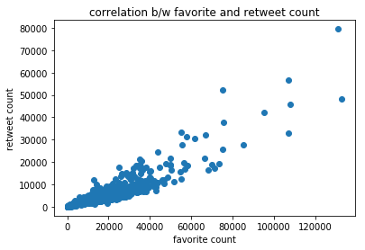

```python
# Correlation b/w retweet count and favourite count

plt.scatter(data= twitter_archive_master, x= 'favorite_count', y= 'retweet_count')
plt.xlabel('favorite count')
plt.ylabel('retweet count')
plt.title('correlation b/w favorite and retweet count');
```

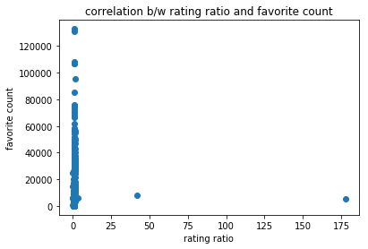

```python
#correlation b/w rating ratio and favorite count

plt.scatter(data= twitter_archive_master, x=twitter_archive_master['rating_numerator']/twitter_archive_master['rating_denominator'], y= 'favorite_count')
plt.xlabel('rating ratio')
plt.ylabel('favorite count')
plt.title('correlation b/w rating ratio and favorite count');
```

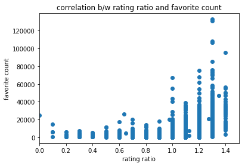

```python
#correlation b/w rating ratio and favorite count when x was limited to remove outlier

plt.scatter(data= twitter_archive_master, x=twitter_archive_master['rating_numerator']/twitter_archive_master['rating_denominator'], y= 'favorite_count')
plt.xlim(0,1.5)
plt.xlabel('rating ratio')
plt.ylabel('favorite count')
plt.title('correlation b/w rating ratio and favorite count');
```

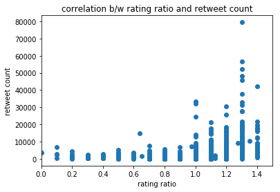

```python
#correlation b/w rating ratio and retweet count

plt.scatter(data= twitter_archive_master, x=twitter_archive_master['rating_numerator']/twitter_archive_master['rating_denominator'], y= 'retweet_count')
plt.xlim(0,1.5)
plt.xlabel('rating ratio')
plt.ylabel('retweet count')
plt.title('correlation b/w rating ratio and retweet count');
```